# 1. Introduction

This summary identifies the validation-best checkpoint and the fine-tuned checkpoints with the smallest probability and loss distance to full retraining. Entropy-selected checkpoints are calculated for Section 7 but are not displayed in this behavioural summary.

```python
# 5.3 Build epoch-sweep summary tables
summary_rows = []
for scenario in scenario_names:
    scenario_results = retain_epoch_sweep_results[
        retain_epoch_sweep_results["scenario"] == scenario
    ].copy()

    fine_tuned_results_only = scenario_results[
        scenario_results["epoch"] > 0
    ].copy()

    validation_best_epoch = validation_best_epochs[scenario]

    overall_entropy_row = scenario_results.loc[
        scenario_results[
            "forget_entropy_mae_to_retraining"
        ].idxmin()
    ]

    overall_probability_row = scenario_results.loc[
        scenario_results[
            "forget_probability_mae_to_retraining"
        ].idxmin()
    ]

    overall_loss_row = scenario_results.loc[
        scenario_results[
            "forget_loss_mae_to_retraining"
        ].idxmin()
    ]

    entropy_row = fine_tuned_results_only.loc[
        fine_tuned_results_only[
            "forget_entropy_mae_to_retraining"
        ].idxmin()
    ]

    probability_row = fine_tuned_results_only.loc[
        fine_tuned_results_only[
            "forget_probability_mae_to_retraining"
        ].idxmin()
    ]

    loss_row = fine_tuned_results_only.loc[
        fine_tuned_results_only[
            "forget_loss_mae_to_retraining"
        ].idxmin()
    ]

    validation_rows = scenario_results[
        scenario_results["epoch"] == validation_best_epoch
    ]
    validation_row = (
        validation_rows.iloc[0]
        if not validation_rows.empty
        else None
    )

    selected_epochs = {
        "validation_best": validation_best_epoch,
        "best_finetuned_entropy": int(entropy_row["epoch"]),
        "best_finetuned_probability": int(probability_row["epoch"]),
        "best_finetuned_loss": int(loss_row["epoch"]),
    }
    all_same = len(set(selected_epochs.values())) == 1

    summary_rows.append(
        {
            "scenario": scenario,
            "display_name": scenario_display_names.get(scenario, scenario),
            "current_validation_best_epoch": validation_best_epoch,
            "overall_epoch_lowest_forget_entropy_distance": int(
                overall_entropy_row["epoch"]
            ),
            "overall_epoch_lowest_forget_probability_distance": int(
                overall_probability_row["epoch"]
            ),
            "overall_epoch_lowest_forget_loss_distance": int(
                overall_loss_row["epoch"]
            ),
            "overall_entropy_best_was_epoch_zero": bool(
                overall_entropy_row["epoch"] == 0
            ),
            "overall_probability_best_was_epoch_zero": bool(
                overall_probability_row["epoch"] == 0
            ),
            "overall_loss_best_was_epoch_zero": bool(
                overall_loss_row["epoch"] == 0
            ),
            "best_finetuned_epoch_for_entropy_distance": int(
                entropy_row["epoch"]
            ),
            "best_finetuned_epoch_for_probability_distance": int(
                probability_row["epoch"]
            ),
            "best_finetuned_epoch_for_loss_distance": int(
                loss_row["epoch"]
            ),
            "selected_checkpoints_all_same": all_same,
            "validation_best_test_f1": np.nan
            if validation_row is None
            else validation_row["test_f1"],
            "entropy_selected_test_f1": entropy_row["test_f1"],
            "probability_selected_test_f1": probability_row["test_f1"],
            "loss_selected_test_f1": loss_row["test_f1"],
            "validation_best_test_f1_delta_from_full_retraining": np.nan
            if validation_row is None
            else validation_row[
                "test_f1_difference_from_full_retraining"
            ],
            "entropy_selected_test_f1_delta_from_full_retraining": entropy_row[
                "test_f1_difference_from_full_retraining"
            ],
            "probability_selected_test_f1_delta_from_full_retraining": probability_row[
                "test_f1_difference_from_full_retraining"
            ],
            "loss_selected_test_f1_delta_from_full_retraining": loss_row[
                "test_f1_difference_from_full_retraining"
            ],
            "entropy_selected_runtime_seconds": entropy_row["runtime_seconds"],
            "probability_selected_runtime_seconds": probability_row[
                "runtime_seconds"
            ],
            "loss_selected_runtime_seconds": loss_row["runtime_seconds"],
        }
    )

retain_epoch_sweep_summary = pd.DataFrame(summary_rows)

behaviour_epoch_sweep_summary = retain_epoch_sweep_summary[
    [
        "scenario",
        "display_name",
        "current_validation_best_epoch",
        "overall_epoch_lowest_forget_probability_distance",
        "overall_epoch_lowest_forget_loss_distance",
        "best_finetuned_epoch_for_probability_distance",
        "best_finetuned_epoch_for_loss_distance",
        "validation_best_test_f1",
        "probability_selected_test_f1",
        "loss_selected_test_f1",
        "validation_best_test_f1_delta_from_full_retraining",
        "probability_selected_test_f1_delta_from_full_retraining",
        "loss_selected_test_f1_delta_from_full_retraining",
        "probability_selected_runtime_seconds",
        "loss_selected_runtime_seconds",
    ]
].copy()

display(behaviour_epoch_sweep_summary)
```

|  | scenario | display_name | current_validation_best_epoch | overall_epoch_lowest_forget_probability_distance | overall_epoch_lowest_forget_loss_distance | best_finetuned_epoch_for_probability_distance | best_finetuned_epoch_for_loss_distance | validation_best_test_f1 | probability_selected_test_f1 | loss_selected_test_f1 | validation_best_test_f1_delta_from_full_retraining | probability_selected_test_f1_delta_from_full_retraining | loss_selected_test_f1_delta_from_full_retraining | probability_selected_runtime_seconds | loss_selected_runtime_seconds |
| --- | --- | --- | --- | --- | --- | --- | --- | --- | --- | --- | --- | --- | --- | --- | --- |
| 0 | s1_random_1_percent | Random 1% | 2 | 0 | 0 | 2 | 2 | 0.671302 | 0.671302 | 0.671302 | -0.005296 | -0.005296 | -0.005296 | 2.373000 | 2.373000 |
| 1 | s2_random_5_percent | Random 5% | 1 | 2 | 2 | 2 | 2 | 0.673724 | 0.679403 | 0.679403 | -0.002185 | 0.003494 | 0.003494 | 2.433941 | 2.433941 |
| 2 | s3_simulated_data_provider_withdrawal | Simulated Data Provider Withdrawal (~5%) | 4 | 2 | 2 | 2 | 2 | 0.672359 | 0.676196 | 0.676196 | 0.004434 | 0.008271 | 0.008271 | 2.273727 | 2.273727 |
| 3 | s4_random_10_percent | Random 10% | 3 | 0 | 2 | 2 | 2 | 0.663202 | 0.677460 | 0.677460 | -0.010650 | 0.003607 | 0.003607 | 2.124290 | 2.124290 |
| 4 | s5_retention_expiry | Simulated Retention Expiry | 1 | 5 | 5 | 5 | 5 | 0.673750 | 0.670243 | 0.670243 | 0.006241 | 0.002734 | 0.002734 | 4.962864 | 4.962864 |

**Prepare entropy interpretation records**

The following cell prepares entropy-specific interpretation records for Section 7. It does not present entropy as behavioural evidence in this section.

```python
interpretation_rows = []
for scenario in scenario_names:
    scenario_results = retain_epoch_sweep_results[
        retain_epoch_sweep_results["scenario"] == scenario
    ].set_index("epoch")
    fine_tuned_scenario_results = scenario_results[
        scenario_results.index > 0
    ]
    display_name = scenario_display_names.get(scenario, scenario)
    epoch_one = scenario_results.loc[1]
    epoch_ten = scenario_results.loc[10]
    best_entropy_epoch = int(
        fine_tuned_scenario_results[
            "forget_entropy_mae_to_retraining"
        ].idxmin()
    )
    best_probability_epoch = int(
        fine_tuned_scenario_results[
            "forget_probability_mae_to_retraining"
        ].idxmin()
    )
    best_loss_epoch = int(
        fine_tuned_scenario_results[
            "forget_loss_mae_to_retraining"
        ].idxmin()
    )
    validation_best_epoch = validation_best_epochs[scenario]
    validation_best = scenario_results.loc[validation_best_epoch]

    epoch_one_closer = epoch_one["relative_entropy_improvement"] > 0
    any_later_epoch_improved_entropy = (
        scenario_results.loc[
            scenario_results.index > 1,
            "forget_entropy_mae_to_retraining",
        ].min()
        < epoch_one["forget_entropy_mae_to_retraining"]
    )
    utility_drop_epoch_ten = epoch_ten["test_f1"] - epoch_one["test_f1"]
    retain_drop_epoch_ten = epoch_ten["retain_f1"] - epoch_one["retain_f1"]

    interpretation_rows.append(
        {
            "scenario": scenario,
            "display_name": display_name,
            "epoch_1_moved_closer_by_entropy": bool(epoch_one_closer),
            "any_later_epoch_improved_entropy_over_epoch_1": bool(
                any_later_epoch_improved_entropy
            ),
            "test_f1_change_epoch_10_minus_epoch_1": utility_drop_epoch_ten,
            "retain_f1_change_epoch_10_minus_epoch_1": retain_drop_epoch_ten,
            "validation_best_epoch": validation_best_epoch,
            "validation_best_relative_entropy_improvement": float(
                validation_best["relative_entropy_improvement"]
            ),
            "validation_best_test_f1_difference_from_full_retraining": float(
                validation_best[
                    "test_f1_difference_from_full_retraining"
                ]
            ),
            "best_entropy_epoch": best_entropy_epoch,
            "best_probability_epoch": best_probability_epoch,
            "best_loss_epoch": best_loss_epoch,
            "structured_scenario": scenario in [
                "s3_simulated_data_provider_withdrawal",
                "s5_retention_expiry",
            ],
        }
    )

retain_epoch_sweep_interpretation = pd.DataFrame(interpretation_rows)
```

**Save epoch-sweep tables**

The epoch-sweep result tables are saved so that later analysis can reuse the checkpoint-level data. The saved detailed tables retain entropy columns for Section 7 while Section 5 presents only the behavioural probability, loss and agreement outputs.

```python
# 5.3 Save epoch-sweep tables and figures
retain_epoch_sweep_results.to_csv(
    extended_tables_dir / "retain_finetuning_epoch_sweep_detailed.csv",
    index=False,
)
retain_epoch_sweep_detailed.to_csv(
    extended_tables_dir / "retain_finetuning_epoch_sweep_reader_table.csv",
    index=False,
)
retain_epoch_sweep_subset_metrics.to_csv(
    extended_tables_dir / "retain_finetuning_epoch_sweep_subset_metrics.csv",
    index=False,
)
retain_epoch_sweep_summary.to_csv(
    extended_tables_dir / "retain_finetuning_epoch_sweep_summary.csv",
    index=False,
)
retain_epoch_sweep_interpretation.to_csv(
    extended_tables_dir / "retain_finetuning_epoch_sweep_interpretation.csv",
    index=False,
)
retain_epoch_sweep_forget_entropy_records.to_csv(
    extended_tables_dir / "retain_finetuning_epoch_sweep_forget_entropy_records.csv",
    index=False,
)
retain_epoch_sweep_training_history.to_csv(
    extended_tables_dir / "retain_finetuning_epoch_sweep_training_history.csv",
    index=False,
)

behaviour_plot_specs = [
    ("forget_probability_mae_to_retraining", "Forget-set probability MAE to full retraining", "forget_probability_mae"),
    ("forget_loss_mae_to_retraining", "Forget-set loss MAE to full retraining", "forget_loss_mae"),
    ("test_f1", "Test F1", "test_f1"),
    ("validation_loss", "Validation loss", "validation_loss"),
    ("retain_f1", "Retain-set F1", "retain_f1"),
]
```

**Save behavioural epoch-sweep figures**

The following figures visualise the probability, loss and utility metrics used in the behavioural evaluation. Entropy figures are generated later in Section 7.1.

```python
saved_figure_paths = []
for scenario in scenario_names:
    display_name = scenario_display_names.get(scenario, scenario)
    scenario_results = retain_epoch_sweep_results[
        retain_epoch_sweep_results["scenario"] == scenario
    ].sort_values("epoch")
    for metric_column, ylabel, filename_suffix in behaviour_plot_specs:
        fig, ax = plt.subplots(figsize=(6, 4))
        ax.plot(
            scenario_results["epoch"],
            scenario_results[metric_column],
            marker="o",
        )
        ax.set_title(f"{display_name}: {ylabel}")
        ax.set_xlabel("Cumulative retain-set fine-tuning epochs")
        ax.set_ylabel(ylabel)
        ax.grid(True, alpha=0.3)
        fig.tight_layout()
        output_path = extended_figures_dir / f"{scenario}_{filename_suffix}.png"
        fig.savefig(output_path, dpi=300, bbox_inches="tight")
        plt.close(fig)
        saved_figure_paths.append(output_path)

    fig, ax = plt.subplots(figsize=(6, 4))
    ax.scatter(
        scenario_results["forget_probability_mae_to_retraining"],
        scenario_results["test_f1"],
    )
    for _, point in scenario_results.iterrows():
        ax.annotate(
            str(int(point["epoch"])),
            (
                point["forget_probability_mae_to_retraining"],
                point["test_f1"],
            ),
            textcoords="offset points",
            xytext=(4, 4),
            fontsize=8,
        )
    ax.set_title(f"{display_name}: Utility-behaviour trade-off")
    ax.set_xlabel("Forget-set probability MAE to full retraining")
    ax.set_ylabel("Test F1")
    ax.grid(True, alpha=0.3)
    fig.tight_layout()
    output_path = extended_figures_dir / f"{scenario}_probability_tradeoff.png"
    fig.savefig(output_path, dpi=300, bbox_inches="tight")
    plt.close(fig)
    saved_figure_paths.append(output_path)
```

**Confirm behavioural epoch-sweep outputs**

This final check reports the saved behavioural epoch-sweep files and figures. Entropy-specific figures are reported in Section 7.1.

```python
print(f"Saved {len(saved_figure_paths)} behavioural epoch-sweep figures to: {extended_figures_dir}")
print(f"Saved epoch-sweep tables to: {extended_tables_dir}")
```

```
Saved 30 behavioural epoch-sweep figures to: ../../results/retain_finetuning/adult/figures/epoch_sweep
Saved epoch-sweep tables to: ../../results/retain_finetuning/adult/tables/epoch_sweep
```

## 5.4 Prediction Agreement

Prediction agreement measures whether two models assign the same binary class labels to the same records. It provides a direct behavioural comparison between fine-tuned, baseline and fully retrained models.

**Prediction agreement with full retraining**

This table compares fine-tuned and fully retrained class labels across all five deletion scenarios.

```python
prediction_agreement_rows = []

for scenario in scenario_names:
    fine_tuned_scenario = finetuned_predictions[
        finetuned_predictions["scenario"] == scenario
    ][["record_index", "y_pred"]]
    retrained_scenario = retrained_predictions[
        retrained_predictions["scenario"] == scenario
    ][["record_index", "y_pred"]]

    merged_predictions = fine_tuned_scenario.merge(
        retrained_scenario,
        on="record_index",
        suffixes=("_finetuned", "_retrained"),
        validate="one_to_one",
    )
    agreement = (
        merged_predictions["y_pred_finetuned"]
        == merged_predictions["y_pred_retrained"]
    ).mean()

    prediction_agreement_rows.append(
        {
            "scenario": scenario,
            "prediction_agreement": agreement,
        }
    )

prediction_agreement = pd.DataFrame(prediction_agreement_rows)

prediction_agreement
```

|  | scenario | prediction_agreement |
| --- | --- | --- |
| 0 | s1_random_1_percent | 0.989900 |
| 1 | s2_random_5_percent | 0.983486 |
| 2 | s3_simulated_data_provider_withdrawal | 0.985533 |
| 3 | s4_random_10_percent | 0.986488 |
| 4 | s5_retention_expiry | 0.985669 |

**Probability difference from the baseline**

This comparison uses the saved baseline predictions to show how far each fine-tuned model moved from the original baseline model.

```python
baseline_predictions_for_comparison = (
    baseline_predictions
    .rename(
        columns={
            "original_index": "record_index",
            "y_probability": "y_prob_baseline",
            "y_pred": "y_pred_baseline",
        }
    )
    [["record_index", "y_prob_baseline", "y_pred_baseline"]]
)

baseline_prediction_shift_rows = []

for scenario in scenario_names:
    scenario_predictions = finetuned_predictions[
        finetuned_predictions["scenario"] == scenario
    ][["record_index", "y_pred", "y_prob"]]

    merged_predictions = scenario_predictions.merge(
        baseline_predictions_for_comparison,
        on="record_index",
        how="inner",
        validate="one_to_one",
    )

    probability_shift = (
        merged_predictions["y_prob"]
        - merged_predictions["y_prob_baseline"]
    ).abs()

    baseline_prediction_shift_rows.append(
        {
            "scenario": scenario,
            "baseline_prediction_agreement": (
                merged_predictions["y_pred"]
                == merged_predictions["y_pred_baseline"]
            ).mean(),
            "mean_absolute_probability_shift_from_baseline": (
                probability_shift.mean()
            ),
        }
    )

baseline_prediction_shift = pd.DataFrame(
    baseline_prediction_shift_rows
)

baseline_prediction_shift
```

|  | scenario | baseline_prediction_agreement | mean_absolute_probability_shift_from_baseline |
| --- | --- | --- | --- |
| 0 | s1_random_1_percent | 0.990310 | 0.009934 |
| 1 | s2_random_5_percent | 0.991265 | 0.007920 |
| 2 | s3_simulated_data_provider_withdrawal | 0.988809 | 0.010255 |
| 3 | s4_random_10_percent | 0.988126 | 0.009845 |
| 4 | s5_retention_expiry | 0.988126 | 0.010058 |

**Forget-set behaviour**

This table focuses on the forget records for each scenario. It compares the baseline, fine-tuned and fully retrained models on the records affected by each deletion request.

```python
forget_behaviour_rows = []

for scenario in scenario_names:
    X_forget = X_train_processed.loc[forget_indices[scenario]]

    baseline_prob, baseline_pred = predict_with_model(
        model=baseline_model,
        features=X_forget,
    )
    retrained_prob, retrained_pred = predict_with_model(
        model=retrained_models[scenario],
        features=X_forget,
    )
    fine_tuned_prob, fine_tuned_pred = predict_with_model(
        model=finetuned_results[scenario]["model"],
        features=X_forget,
    )

    forget_behaviour_rows.append(
        {
            "scenario": scenario,
            "baseline_retrained_prediction_agreement": (
                baseline_pred == retrained_pred
            ).mean(),
            "finetuned_retrained_prediction_agreement": (
                fine_tuned_pred == retrained_pred
            ).mean(),
            "baseline_retrained_probability_difference": np.mean(
                np.abs(baseline_prob - retrained_prob)
            ),
            "finetuned_retrained_probability_difference": np.mean(
                np.abs(fine_tuned_prob - retrained_prob)
            ),
        }
    )

forget_behaviour = pd.DataFrame(forget_behaviour_rows)

forget_behaviour
```

|  | scenario | baseline_retrained_prediction_agreement | finetuned_retrained_prediction_agreement | baseline_retrained_probability_difference | finetuned_retrained_probability_difference |
| --- | --- | --- | --- | --- | --- |
| 0 | s1_random_1_percent | 0.988304 | 0.988304 | 0.010891 | 0.011010 |
| 1 | s2_random_5_percent | 0.984201 | 0.986542 | 0.013411 | 0.011669 |
| 2 | s3_simulated_data_provider_withdrawal | 0.985277 | 0.987044 | 0.013070 | 0.014124 |
| 3 | s4_random_10_percent | 0.985083 | 0.983621 | 0.014625 | 0.015063 |
| 4 | s5_retention_expiry | 0.945748 | 0.960430 | 0.036116 | 0.027758 |

## 5.5 Behavioural Evaluation Summary

The behavioural summary combines probability distance, prediction agreement and forget-set comparisons. These tables are used later to describe how closely fine-tuning reproduces the full-retraining reference.

```python
probability_distance_rows = []

for scenario in scenario_names:
    fine_tuned_scenario = finetuned_predictions[
        finetuned_predictions["scenario"] == scenario
    ][["record_index", "y_prob"]]

    retrained_scenario = retrained_predictions[
        retrained_predictions["scenario"] == scenario
    ][["record_index", "y_prob"]]

    merged_probabilities = fine_tuned_scenario.merge(
        retrained_scenario,
        on="record_index",
        suffixes=("_finetuned", "_retrained"),
        validate="one_to_one",
    )

    absolute_difference = (
        merged_probabilities["y_prob_finetuned"]
        - merged_probabilities["y_prob_retrained"]
    ).abs()

    probability_distance_rows.append(
        {
            "scenario": scenario,
            "mean_absolute_probability_difference": float(
                absolute_difference.mean()
            ),
            "median_absolute_probability_difference": float(
                absolute_difference.median()
            ),
            "maximum_absolute_probability_difference": float(
                absolute_difference.max()
            ),
        }
    )

probability_distance_summary = pd.DataFrame(
    probability_distance_rows
)

probability_distance_summary
```

|  | scenario | mean_absolute_probability_difference | median_absolute_probability_difference | maximum_absolute_probability_difference |
| --- | --- | --- | --- | --- |
| 0 | s1_random_1_percent | 0.010496 | 0.004003 | 0.203127 |
| 1 | s2_random_5_percent | 0.011196 | 0.004133 | 0.237666 |
| 2 | s3_simulated_data_provider_withdrawal | 0.013767 | 0.005715 | 0.292252 |
| 3 | s4_random_10_percent | 0.015660 | 0.005732 | 0.213568 |
| 4 | s5_retention_expiry | 0.013607 | 0.004446 | 0.268171 |

**Summary**

We can see this directly in the numbers: for S1, the fine-tuned model agrees with the retrained model on 98.83% of forget-set predictions — and the untouched baseline also agrees on 98.83%, showing that fine-tuning changed nothing. For S4, fine-tuning actually made things slightly worse, agreeing with how the retrained model dropped from 98.51% (baseline) to 98.36% (fine-tuned).

Only the two structured scenarios (S3 and S5) show fine-tuning clearly helping with S5 making the clearest case: the baseline's agreement with the retrained model starts at just 94.57% — much lower than the ~98–99% seen in the random scenarios — and fine-tuning lifts it to 96.04%. That's a real, measurable improvement, because there was a real gap to begin with. The reason there was a gap at all: S5's forget set isn't random — it's built around workclass-linked synthetic dates, so it's systematically different from the rest of the data (30.8% high-income vs. 22.6% in the retain set). Removing a chunk that's genuinely different actually changes what the model should learn, giving fine-tuning real work to do — unlike the random scenarios, where there was barely a difference to fix in the first place.

# 6. Utility Evaluation

Utility evaluation measures whether retain-set fine-tuning preserves predictive performance on the unchanged test set after unlearning. The following sections evaluate test-set performance, compare it with full retraining and summarise utility preservation across all deletion scenarios.

## 6.1 Test-Set Classification Performance

This section evaluates each fine-tuned model on the unchanged test set. Classification metrics, classification reports and confusion matrices are generated for every deletion scenario to assess predictive performance after retain-set fine-tuning.

```
Classification report: s1_random_1_percent
              precision    recall  f1-score   support

           0       0.89      0.93      0.91      5574
           1       0.75      0.62      0.68      1753

    accuracy                           0.86      7327
   macro avg       0.82      0.78      0.79      7327
weighted avg       0.85      0.86      0.85      7327
```

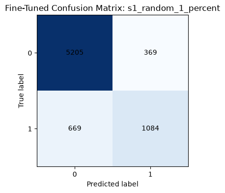

```
Classification report: s2_random_5_percent
              precision    recall  f1-score   support

           0       0.89      0.93      0.91      5574
           1       0.74      0.62      0.67      1753

    accuracy                           0.86      7327
   macro avg       0.81      0.77      0.79      7327
weighted avg       0.85      0.86      0.85      7327
```

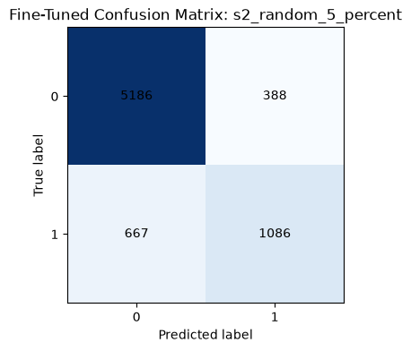

```
Classification report: s3_simulated_data_provider_withdrawal
              precision    recall  f1-score   support

           0       0.89      0.93      0.91      5574
           1       0.74      0.63      0.68      1753

    accuracy                           0.86      7327
   macro avg       0.81      0.78      0.79      7327
weighted avg       0.85      0.86      0.85      7327
```

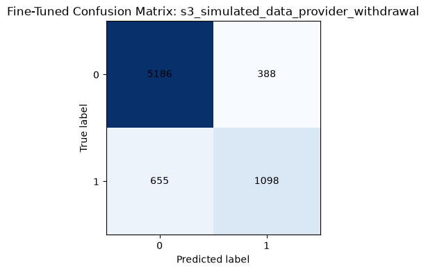

```
Classification report: s4_random_10_percent
              precision    recall  f1-score   support

           0       0.89      0.93      0.91      5574
           1       0.74      0.63      0.68      1753

    accuracy                           0.86      7327
   macro avg       0.81      0.78      0.79      7327
weighted avg       0.85      0.86      0.85      7327
```

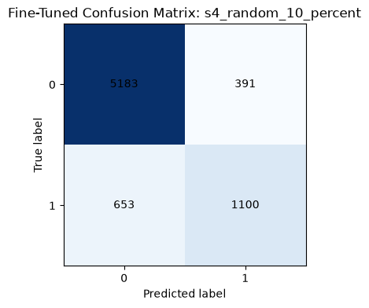

```
Classification report: s5_retention_expiry
              precision    recall  f1-score   support

           0       0.89      0.93      0.91      5574
           1       0.74      0.62      0.68      1753

    accuracy                           0.86      7327
   macro avg       0.81      0.78      0.79      7327
weighted avg       0.85      0.86      0.85      7327
```

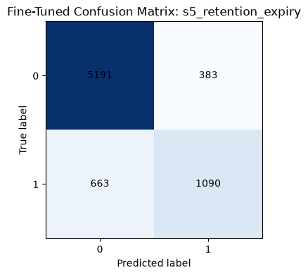

|  | scenario | accuracy | precision | recall | f1_score | roc_auc |
| --- | --- | --- | --- | --- | --- | --- |
| 0 | s1_random_1_percent | 0.858332 | 0.746043 | 0.618369 | 0.676232 | 0.909771 |
| 1 | s2_random_5_percent | 0.856012 | 0.736771 | 0.619509 | 0.673071 | 0.909598 |
| 2 | s3_simulated_data_provider_withdrawal | 0.857650 | 0.738896 | 0.626355 | 0.677987 | 0.909919 |
| 3 | s4_random_10_percent | 0.857513 | 0.737760 | 0.627496 | 0.678175 | 0.909673 |
| 4 | s5_retention_expiry | 0.857240 | 0.739986 | 0.621791 | 0.675759 | 0.909646 |

|  | scenario | label | precision | recall | f1_score | support |
| --- | --- | --- | --- | --- | --- | --- |
| 0 | s1_random_1_percent | 0 | 0.886108 | 0.933800 | 0.909329 | 5574.0 |
| 1 | s1_random_1_percent | 1 | 0.746043 | 0.618369 | 0.676232 | 1753.0 |
| 2 | s1_random_1_percent | accuracy | NaN | NaN | 0.858332 | NaN |
| 3 | s1_random_1_percent | macro avg | 0.816075 | 0.776084 | 0.792781 | 7327.0 |
| 4 | s1_random_1_percent | weighted avg | 0.852597 | 0.858332 | 0.853560 | 7327.0 |
| 5 | s2_random_5_percent | 0 | 0.886041 | 0.930391 | 0.907675 | 5574.0 |
| 6 | s2_random_5_percent | 1 | 0.736771 | 0.619509 | 0.673071 | 1753.0 |
| 7 | s2_random_5_percent | accuracy | NaN | NaN | 0.856012 | NaN |
| 8 | s2_random_5_percent | macro avg | 0.811406 | 0.774950 | 0.790373 | 7327.0 |
| 9 | s2_random_5_percent | weighted avg | 0.850328 | 0.856012 | 0.851545 | 7327.0 |
| 10 | s3_simulated_data_provider_withdrawal | 0 | 0.887862 | 0.930391 | 0.908629 | 5574.0 |
| 11 | s3_simulated_data_provider_withdrawal | 1 | 0.738896 | 0.626355 | 0.677987 | 1753.0 |
| 12 | s3_simulated_data_provider_withdrawal | accuracy | NaN | NaN | 0.857650 | NaN |
| 13 | s3_simulated_data_provider_withdrawal | macro avg | 0.813379 | 0.778373 | 0.793308 | 7327.0 |
| 14 | s3_simulated_data_provider_withdrawal | weighted avg | 0.852221 | 0.857650 | 0.853447 | 7327.0 |
| 15 | s4_random_10_percent | 0 | 0.888108 | 0.929853 | 0.908501 | 5574.0 |
| 16 | s4_random_10_percent | 1 | 0.737760 | 0.627496 | 0.678175 | 1753.0 |
| 17 | s4_random_10_percent | accuracy | NaN | NaN | 0.857513 | NaN |
| 18 | s4_random_10_percent | macro avg | 0.812934 | 0.778674 | 0.793338 | 7327.0 |
| 19 | s4_random_10_percent | weighted avg | 0.852137 | 0.857513 | 0.853395 | 7327.0 |
| 20 | s5_retention_expiry | 0 | 0.886744 | 0.931288 | 0.908470 | 5574.0 |
| 21 | s5_retention_expiry | 1 | 0.739986 | 0.621791 | 0.675759 | 1753.0 |
| 22 | s5_retention_expiry | accuracy | NaN | NaN | 0.857240 | NaN |
| 23 | s5_retention_expiry | macro avg | 0.813365 | 0.776540 | 0.792115 | 7327.0 |
| 24 | s5_retention_expiry | weighted avg | 0.851632 | 0.857240 | 0.852794 | 7327.0 |

|  | scenario | true_negative | false_positive | false_negative | true_positive |
| --- | --- | --- | --- | --- | --- |
| 0 | s1_random_1_percent | 5205 | 369 | 669 | 1084 |
| 1 | s2_random_5_percent | 5186 | 388 | 667 | 1086 |
| 2 | s3_simulated_data_provider_withdrawal | 5186 | 388 | 655 | 1098 |
| 3 | s4_random_10_percent | 5183 | 391 | 653 | 1100 |
| 4 | s5_retention_expiry | 5191 | 383 | 663 | 1090 |

```python
scenario_evaluation_results = []
mia_result_frames = []

for scenario in scenario_names:
    scenario_evaluation_results.append(
        evaluate_scenario(
            scenario_name=scenario,
            predictions_df=finetuned_predictions,
        )
    )
    mia_result_frames.append(
        evaluate_membership_attack_scenario(scenario)
    )

metrics_rows = [
    result["metrics"]
    for result in scenario_evaluation_results
]
classification_report_rows = [
    row
    for result in scenario_evaluation_results
    for row in result["classification_report_rows"]
]
confusion_matrix_rows = [
    result["confusion_matrix"]
    for result in scenario_evaluation_results
]
confusion_matrix_figures = {
    result["scenario"]: result["confusion_matrix_figure"]
    for result in scenario_evaluation_results
}

finetuned_metrics = pd.DataFrame(metrics_rows)
classification_reports_df = pd.DataFrame(classification_report_rows)
confusion_matrices_df = pd.DataFrame(confusion_matrix_rows)
mia_results_v2 = pd.concat(mia_result_frames, ignore_index=True)
ordered_mia_columns = [
    "scenario",
    "model",
    "attack_type",
    "member_set",
    "non_member_set",
    "attack_auc",
    "attack_auc_ci_low",
    "attack_auc_ci_high",
    "tpr_at_fpr_0.001",
    "tpr_at_fpr_0.01",
    "tpr_at_fpr_0.05",
    "permutation_p_value",
    "mean_member_score",
    "mean_non_member_score",
    "attack_auc_bootstrap_mean",
    "threshold_balanced_attack_accuracy",
    "attack_threshold",
    "member_count",
    "non_member_count",
]
mia_results_v2 = mia_results_v2[ordered_mia_columns]
mia_results = mia_results_v2.copy()
mia_summary = (
    mia_results_v2
    .sort_values("attack_auc", ascending=False)
    .reset_index(drop=True)
)

display(finetuned_metrics)
display(classification_reports_df)
confusion_matrices_df
```

## 6.2 Utility Comparison with Full Retraining

The test-set utility of each fine-tuned model is compared with its corresponding fully retrained reference model. Differences in accuracy, precision, recall, F1 score and AUROC quantify how closely retain-set fine-tuning preserves predictive performance relative to full retraining.

```python
retraining_comparison = finetuned_metrics.merge(
    retrained_metrics_for_comparison,
    on="scenario",
    suffixes=("_finetuned", "_retrained"),
)
retraining_comparison["accuracy_difference"] = (
    retraining_comparison["accuracy_finetuned"]
    - retraining_comparison["accuracy_retrained"]
)
retraining_comparison["precision_difference"] = (
    retraining_comparison["precision_finetuned"]
    - retraining_comparison["precision_retrained"]
)
retraining_comparison["recall_difference"] = (
    retraining_comparison["recall_finetuned"]
    - retraining_comparison["recall_retrained"]
)
retraining_comparison["f1_score_difference"] = (
    retraining_comparison["f1_score_finetuned"]
    - retraining_comparison["f1_score_retrained"]
)
retraining_comparison["roc_auc_difference"] = (
    retraining_comparison["roc_auc_finetuned"]
    - retraining_comparison["roc_auc_retrained"]
)

retraining_comparison
```

|  | scenario | accuracy_finetuned | precision_finetuned | recall_finetuned | f1_score_finetuned | roc_auc_finetuned | display_name | forget_count | forget_percentage | retain_count | ... | roc_auc_difference_from_baseline | actual_epochs_run | runtime_seconds | precision_retrained | recall_retrained | accuracy_difference | precision_difference | recall_difference | f1_score_difference | roc_auc_difference |
| --- | --- | --- | --- | --- | --- | --- | --- | --- | --- | --- | --- | --- | --- | --- | --- | --- | --- | --- | --- | --- | --- |
| 0 | s1_random_1_percent | 0.858332 | 0.746043 | 0.618369 | 0.676232 | 0.909771 | Random 1% | 342 | 1.000322 | 33847 | ... | 0.000199 | 12 | 6.158163 | 0.742001 | 0.621791 | 0.000546 | 0.004041 | -0.003423 | -0.000366 | -0.000085 |
| 1 | s2_random_5_percent | 0.856012 | 0.736771 | 0.619509 | 0.673071 | 0.909598 | Random 5% | 1709 | 4.998684 | 32480 | ... | -0.000297 | 15 | 6.309743 | 0.734762 | 0.625784 | -0.000409 | 0.002008 | -0.006275 | -0.002838 | 0.000239 |
| 2 | s3_simulated_data_provider_withdrawal | 0.857650 | 0.738896 | 0.626355 | 0.677987 | 0.909919 | Simulated Data Provider Withdrawal (~5%) | 1698 | 4.966510 | 32491 | ... | 0.000486 | 11 | 4.582676 | 0.745084 | 0.605248 | 0.001638 | -0.006188 | 0.021107 | 0.010061 | -0.000224 |
| 3 | s4_random_10_percent | 0.857513 | 0.737760 | 0.627496 | 0.678175 | 0.909673 | Random 10% | 3419 | 10.000292 | 30770 | ... | -0.000219 | 13 | 5.082448 | 0.732262 | 0.624073 | 0.002047 | 0.005498 | 0.003423 | 0.004322 | 0.000235 |
| 4 | s5_retention_expiry | 0.857240 | 0.739986 | 0.621791 | 0.675759 | 0.909646 | Simulated Retention Expiry | 5585 | 16.335664 | 28604 | ... | -0.001220 | 14 | 5.083569 | 0.747525 | 0.602966 | 0.000955 | -0.007538 | 0.018825 | 0.008251 | 0.001210 |

5 rows × 27 columns

**ROC curve comparison**

ROC curves are generated for each fine-tuned model to visualise ranking performance across all decision thresholds. AUROC is included because it measures threshold-independent classification performance and provides an additional utility comparison across deletion scenarios.

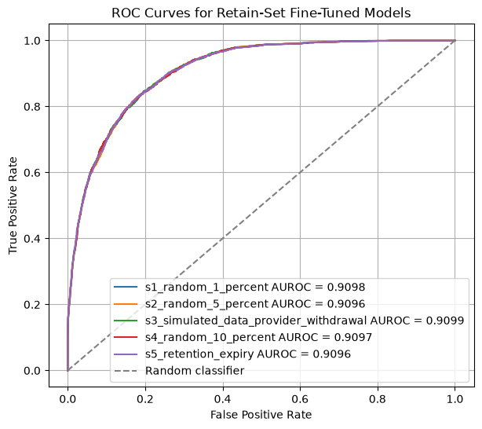

|  | scenario | false_positive_rate | true_positive_rate | threshold |
| --- | --- | --- | --- | --- |
| 0 | s1_random_1_percent | 0.000000 | 0.000000 | inf |
| 1 | s1_random_1_percent | 0.000000 | 0.022818 | 1.000000 |
| 2 | s1_random_1_percent | 0.000000 | 0.108956 | 0.950471 |
| 3 | s1_random_1_percent | 0.000179 | 0.108956 | 0.948827 |
| 4 | s1_random_1_percent | 0.000179 | 0.110097 | 0.947783 |

```python
roc_curve_rows = []

roc_fig, roc_ax = plt.subplots(figsize=(7, 6))

for scenario, scenario_predictions in finetuned_predictions.groupby(
    "scenario"
):
    false_positive_rate, true_positive_rate, thresholds = roc_curve(
        scenario_predictions["y_true"],
        scenario_predictions["y_prob"],
    )
    scenario_auc = roc_auc_score(
        scenario_predictions["y_true"],
        scenario_predictions["y_prob"],
    )

    roc_ax.plot(
        false_positive_rate,
        true_positive_rate,
        label=f"{scenario} AUROC = {scenario_auc:.4f}",
    )

    for fpr, tpr, threshold in zip(
        false_positive_rate,
        true_positive_rate,
        thresholds,
    ):
        roc_curve_rows.append(
            {
                "scenario": scenario,
                "false_positive_rate": fpr,
                "true_positive_rate": tpr,
                "threshold": threshold,
            }
        )

roc_ax.plot(
    [0, 1],
    [0, 1],
    linestyle="--",
    color="gray",
    label="Random classifier",
)
roc_ax.set_xlabel("False Positive Rate")
roc_ax.set_ylabel("True Positive Rate")
roc_ax.set_title("ROC Curves for Retain-Set Fine-Tuned Models")
roc_ax.legend()
roc_ax.grid(True)
plt.show()

roc_curves_df = pd.DataFrame(roc_curve_rows)

roc_curves_df.head()
```

## 6.3 Utility Evaluation Summary

The utility summary compares each fine-tuned model with the original baseline model using the primary utility metrics. Differences in accuracy, F1 score and AUROC indicate whether retain-set fine-tuning preserves predictive performance relative to the original model before unlearning.

```python
baseline_metric_values = baseline_metrics.set_index("metric")["value"]

baseline_comparison = finetuned_metrics.copy()
baseline_comparison["baseline_accuracy"] = baseline_metric_values.loc[
    "accuracy"
]
baseline_comparison["baseline_f1_score"] = baseline_metric_values.loc[
    "f1_score"
]
baseline_comparison["baseline_roc_auc"] = baseline_metric_values.loc[
    "roc_auc"
]
baseline_comparison["accuracy_vs_baseline"] = (
    baseline_comparison["accuracy"]
    - baseline_comparison["baseline_accuracy"]
)
baseline_comparison["f1_score_vs_baseline"] = (
    baseline_comparison["f1_score"]
    - baseline_comparison["baseline_f1_score"]
)
baseline_comparison["roc_auc_vs_baseline"] = (
    baseline_comparison["roc_auc"]
    - baseline_comparison["baseline_roc_auc"]
)

baseline_comparison[
    [
        "scenario",
        "baseline_accuracy",
        "accuracy",
        "accuracy_vs_baseline",
        "baseline_f1_score",
        "f1_score",
        "f1_score_vs_baseline",
        "baseline_roc_auc",
        "roc_auc",
        "roc_auc_vs_baseline",
    ]
]
```

|  | scenario | baseline_accuracy | accuracy | accuracy_vs_baseline | baseline_f1_score | f1_score | f1_score_vs_baseline | baseline_roc_auc | roc_auc | roc_auc_vs_baseline |
| --- | --- | --- | --- | --- | --- | --- | --- | --- | --- | --- |
| 0 | s1_random_1_percent | 0.856012 | 0.858332 | 0.002320 | 0.675085 | 0.676232 | 0.001147 | 0.909657 | 0.909771 | 0.000114 |
| 1 | s2_random_5_percent | 0.856012 | 0.856012 | 0.000000 | 0.675085 | 0.673071 | -0.002014 | 0.909657 | 0.909598 | -0.000058 |
| 2 | s3_simulated_data_provider_withdrawal | 0.856012 | 0.857650 | 0.001638 | 0.675085 | 0.677987 | 0.002902 | 0.909657 | 0.909919 | 0.000262 |
| 3 | s4_random_10_percent | 0.856012 | 0.857513 | 0.001501 | 0.675085 | 0.678175 | 0.003090 | 0.909657 | 0.909673 | 0.000016 |
| 4 | s5_retention_expiry | 0.856012 | 0.857240 | 0.001228 | 0.675085 | 0.675759 | 0.000675 | 0.909657 | 0.909646 | -0.000010 |

**Summary**

These results show that retain-set fine-tuning preserves model utility. However, this does not necessarily mean that the method successfully removed the influence of the forget records. In the random-deletion scenarios, predictive performance remained stable even where Section 5 found limited similarity to full retraining. Utility preservation and similarity to full retraining must therefore be evaluated separately.

# 7. Forgetfulness Evaluation

Forgetfulness evaluation examines empirical evidence on records associated with deletion requests. Entropy is used as a model-uncertainty diagnostic on forget records, while membership inference evaluates whether training membership remains detectable. Both are empirical diagnostics and are compared against the fully retrained reference model where appropriate.

## 7.1 Entropy-Based Forgetfulness Evaluation

Predictive entropy measures how uncertain the model is about its prediction. Normalised entropy values close to 0 represent confident predictions, while values close to 1 represent greater uncertainty.

In this notebook, entropy is evaluated on the forget records for the original baseline, retain-set fine-tuned and fully retrained models. The fully retrained model provides the reference because it was trained without the forget records. If fine-tuning moves the entropy values on the forget records towards those produced by full retraining, this provides evidence consistent with forgetting.

Entropy is treated as a forgetfulness measure rather than a predictive-utility or general behavioural metric. It provides empirical evidence but does not prove that the influence of every individual record has been completely removed.

**Entropy epoch-sweep tables**

The following tables present the existing entropy outputs from the epoch sweep. They include forget-set mean entropy, entropy distance to full retraining, baseline entropy distance, relative entropy improvement, Wasserstein distance and the percentage of forget records that moved closer to the fully retrained reference by entropy.

```python
entropy_epoch_sweep_detailed = retain_epoch_sweep_detailed[
    [
        "scenario",
        "display_name",
        "epoch",
        "forget_entropy_mean",
        "forget_entropy_mae_to_retraining",
        "baseline_entropy_mae_to_retraining",
        "relative_entropy_improvement",
        "forget_entropy_wasserstein_to_retraining",
        "entropy_records_moved_closer_percentage",
    ]
].copy()

entropy_epoch_sweep_summary = retain_epoch_sweep_summary[
    [
        "scenario",
        "display_name",
        "overall_epoch_lowest_forget_entropy_distance",
        "overall_entropy_best_was_epoch_zero",
        "best_finetuned_epoch_for_entropy_distance",
        "entropy_selected_test_f1",
        "entropy_selected_test_f1_delta_from_full_retraining",
        "entropy_selected_runtime_seconds",
    ]
].copy()

display(entropy_epoch_sweep_detailed)
display(entropy_epoch_sweep_summary)
retain_epoch_sweep_interpretation
```

|  | scenario | display_name | epoch | forget_entropy_mean | forget_entropy_mae_to_retraining | baseline_entropy_mae_to_retraining | relative_entropy_improvement | forget_entropy_wasserstein_to_retraining | entropy_records_moved_closer_percentage |
| --- | --- | --- | --- | --- | --- | --- | --- | --- | --- |
| 0 | s1_random_1_percent | Random 1% | 0 | 0.420806 | 0.017910 | 0.017910 | 0.000000 | 0.008703 | 0.000000 |
| 1 | s1_random_1_percent | Random 1% | 1 | 0.394427 | 0.040633 | 0.017910 | -1.268669 | 0.021194 | 15.497076 |
| 2 | s1_random_1_percent | Random 1% | 2 | 0.407544 | 0.021783 | 0.017910 | -0.216227 | 0.009010 | 35.964912 |
| 3 | s1_random_1_percent | Random 1% | 3 | 0.428989 | 0.025768 | 0.017910 | -0.438718 | 0.016503 | 30.994152 |
| 4 | s1_random_1_percent | Random 1% | 5 | 0.411501 | 0.028479 | 0.017910 | -0.590063 | 0.011062 | 26.315789 |
| 5 | s1_random_1_percent | Random 1% | 8 | 0.404034 | 0.028313 | 0.017910 | -0.580845 | 0.012301 | 29.824561 |
| 6 | s1_random_1_percent | Random 1% | 10 | 0.419963 | 0.029539 | 0.017910 | -0.649272 | 0.010715 | 27.192982 |
| 7 | s2_random_5_percent | Random 5% | 0 | 0.447624 | 0.021005 | 0.021005 | 0.000000 | 0.006780 | 0.000000 |
| 8 | s2_random_5_percent | Random 5% | 1 | 0.439058 | 0.026634 | 0.021005 | -0.267940 | 0.014896 | 36.922177 |
| 9 | s2_random_5_percent | Random 5% | 2 | 0.442574 | 0.021728 | 0.021005 | -0.034380 | 0.011603 | 40.140433 |
| 10 | s2_random_5_percent | Random 5% | 3 | 0.449506 | 0.022517 | 0.021005 | -0.071937 | 0.006181 | 38.970158 |
| 11 | s2_random_5_percent | Random 5% | 5 | 0.449178 | 0.022893 | 0.021005 | -0.089883 | 0.006238 | 35.108250 |
| 12 | s2_random_5_percent | Random 5% | 8 | 0.439093 | 0.026776 | 0.021005 | -0.274714 | 0.014827 | 31.129315 |
| 13 | s2_random_5_percent | Random 5% | 10 | 0.433246 | 0.029326 | 0.021005 | -0.396110 | 0.020660 | 28.203628 |
| 14 | s3_simulated_data_provider_withdrawal | Simulated Data Provider Withdrawal (~5%) | 0 | 0.448216 | 0.023212 | 0.023212 | 0.000000 | 0.009781 | 0.000000 |
| 15 | s3_simulated_data_provider_withdrawal | Simulated Data Provider Withdrawal (~5%) | 1 | 0.441807 | 0.022300 | 0.023212 | 0.039272 | 0.004726 | 50.706714 |
| 16 | s3_simulated_data_provider_withdrawal | Simulated Data Provider Withdrawal (~5%) | 2 | 0.439710 | 0.020303 | 0.023212 | 0.125303 | 0.004397 | 51.236749 |
| 17 | s3_simulated_data_provider_withdrawal | Simulated Data Provider Withdrawal (~5%) | 3 | 0.441887 | 0.025873 | 0.023212 | -0.114650 | 0.006127 | 39.458186 |
| 18 | s3_simulated_data_provider_withdrawal | Simulated Data Provider Withdrawal (~5%) | 4 | 0.427128 | 0.025230 | 0.023212 | -0.086951 | 0.011403 | 41.224971 |
| 19 | s3_simulated_data_provider_withdrawal | Simulated Data Provider Withdrawal (~5%) | 5 | 0.427810 | 0.023321 | 0.023212 | -0.004720 | 0.010743 | 43.404005 |
| 20 | s3_simulated_data_provider_withdrawal | Simulated Data Provider Withdrawal (~5%) | 8 | 0.429825 | 0.029348 | 0.023212 | -0.264359 | 0.009155 | 35.394582 |
| 21 | s3_simulated_data_provider_withdrawal | Simulated Data Provider Withdrawal (~5%) | 10 | 0.431733 | 0.029062 | 0.023212 | -0.252021 | 0.008079 | 34.452297 |
| 22 | s4_random_10_percent | Random 10% | 0 | 0.441483 | 0.024447 | 0.024447 | 0.000000 | 0.007373 | 0.000000 |
| 23 | s4_random_10_percent | Random 10% | 1 | 0.441467 | 0.029042 | 0.024447 | -0.187965 | 0.009849 | 35.361217 |
| 24 | s4_random_10_percent | Random 10% | 2 | 0.431517 | 0.025047 | 0.024447 | -0.024559 | 0.005139 | 43.375256 |
| 25 | s4_random_10_percent | Random 10% | 3 | 0.431248 | 0.029338 | 0.024447 | -0.200083 | 0.007038 | 33.079848 |
| 26 | s4_random_10_percent | Random 10% | 5 | 0.434929 | 0.027359 | 0.024447 | -0.119112 | 0.009645 | 36.209418 |
| 27 | s4_random_10_percent | Random 10% | 8 | 0.410349 | 0.036618 | 0.024447 | -0.497859 | 0.024266 | 27.493419 |
| 28 | s4_random_10_percent | Random 10% | 10 | 0.411924 | 0.037338 | 0.024447 | -0.527318 | 0.022692 | 27.785902 |
| 29 | s5_retention_expiry | Simulated Retention Expiry | 0 | 0.551749 | 0.051003 | 0.051003 | 0.000000 | 0.024890 | 0.000000 |
| 30 | s5_retention_expiry | Simulated Retention Expiry | 1 | 0.540358 | 0.038786 | 0.051003 | 0.239529 | 0.013505 | 66.338406 |
| 31 | s5_retention_expiry | Simulated Retention Expiry | 2 | 0.518119 | 0.033837 | 0.051003 | 0.336559 | 0.008824 | 62.041182 |
| 32 | s5_retention_expiry | Simulated Retention Expiry | 3 | 0.519012 | 0.033657 | 0.051003 | 0.340091 | 0.008543 | 61.700985 |
| 33 | s5_retention_expiry | Simulated Retention Expiry | 5 | 0.517942 | 0.030884 | 0.051003 | 0.394462 | 0.009788 | 63.419875 |
| 34 | s5_retention_expiry | Simulated Retention Expiry | 8 | 0.511782 | 0.033605 | 0.051003 | 0.341114 | 0.015159 | 58.352731 |
| 35 | s5_retention_expiry | Simulated Retention Expiry | 10 | 0.507558 | 0.036610 | 0.051003 | 0.282196 | 0.019382 | 54.897046 |

|  | scenario | display_name | overall_epoch_lowest_forget_entropy_distance | overall_entropy_best_was_epoch_zero | best_finetuned_epoch_for_entropy_distance | entropy_selected_test_f1 | entropy_selected_test_f1_delta_from_full_retraining | entropy_selected_runtime_seconds |
| --- | --- | --- | --- | --- | --- | --- | --- | --- |
| 0 | s1_random_1_percent | Random 1% | 0 | True | 2 | 0.671302 | -0.005296 | 2.373000 |
| 1 | s2_random_5_percent | Random 5% | 0 | True | 2 | 0.679403 | 0.003494 | 2.433941 |
| 2 | s3_simulated_data_provider_withdrawal | Simulated Data Provider Withdrawal (~5%) | 2 | False | 2 | 0.676196 | 0.008271 | 2.273727 |
| 3 | s4_random_10_percent | Random 10% | 0 | True | 2 | 0.677460 | 0.003607 | 2.124290 |
| 4 | s5_retention_expiry | Simulated Retention Expiry | 5 | False | 5 | 0.670243 | 0.002734 | 4.962864 |

|  | scenario | display_name | epoch_1_moved_closer_by_entropy | any_later_epoch_improved_entropy_over_epoch_1 | test_f1_change_epoch_10_minus_epoch_1 | retain_f1_change_epoch_10_minus_epoch_1 | validation_best_epoch | validation_best_relative_entropy_improvement | validation_best_test_f1_difference_from_full_retraining | best_entropy_epoch | best_probability_epoch | best_loss_epoch | structured_scenario |
| --- | --- | --- | --- | --- | --- | --- | --- | --- | --- | --- | --- | --- | --- |
| 0 | s1_random_1_percent | Random 1% | False | True | 0.014998 | 0.023037 | 2 | -0.216227 | -0.005296 | 2 | 2 | 2 | False |
| 1 | s2_random_5_percent | Random 5% | False | True | 0.003134 | 0.013709 | 1 | -0.267940 | -0.002185 | 2 | 2 | 2 | False |
| 2 | s3_simulated_data_provider_withdrawal | Simulated Data Provider Withdrawal (~5%) | True | True | 0.004359 | 0.019965 | 4 | -0.086951 | 0.004434 | 2 | 2 | 2 | True |
| 3 | s4_random_10_percent | Random 10% | False | True | -0.004609 | 0.008927 | 3 | -0.200083 | -0.010650 | 2 | 2 | 2 | False |
| 4 | s5_retention_expiry | Simulated Retention Expiry | True | True | -0.005833 | 0.012284 | 1 | 0.239529 | 0.006241 | 5 | 5 | 5 | True |

**Entropy scenario interpretation**

The following output prints the existing entropy-specific scenario interpretation. It reports whether the first fine-tuning epoch moved entropy closer to full retraining, whether any later evaluated epoch improved entropy fidelity further, and the validation-best checkpoint's entropy and test-F1 measurements.

```python
for _, row in retain_epoch_sweep_interpretation.iterrows():
    print(f"\n{row['display_name']} ({row['scenario']})")
    print(
        "Epoch 1 "
        + ("moved closer" if row["epoch_1_moved_closer_by_entropy"] else "did not move closer")
        + " to the full-retraining reference by entropy MAE."
    )
    print(
        "At least one later epoch improved entropy fidelity relative to epoch 1."
        if row[
            "any_later_epoch_improved_entropy_over_epoch_1"
        ]
        else "No later evaluated epoch improved entropy fidelity relative to epoch 1."
    )
    print(
        f"Epoch 10 minus epoch 1 test F1 change: {row['test_f1_change_epoch_10_minus_epoch_1']:.4f}; "
        f"retain F1 change: {row['retain_f1_change_epoch_10_minus_epoch_1']:.4f}."
    )
    print(
        f"Validation-best epoch {row['validation_best_epoch']} had "
        f"a relative entropy improvement of "
        f"{row['validation_best_relative_entropy_improvement']:.4f} "
        f"and a test F1 difference from full retraining of "
        f"{row['validation_best_test_f1_difference_from_full_retraining']:.4f}."
    )
```

```
Random 1% (s1_random_1_percent)
Epoch 1 did not move closer to the full-retraining reference by entropy MAE.
At least one later epoch improved entropy fidelity relative to epoch 1.
Epoch 10 minus epoch 1 test F1 change: 0.0150; retain F1 change: 0.0230.
Validation-best epoch 2 had a relative entropy improvement of -0.2162 and a test F1 difference from full retraining of -0.0053.

Random 5% (s2_random_5_percent)
Epoch 1 did not move closer to the full-retraining reference by entropy MAE.
At least one later epoch improved entropy fidelity relative to epoch 1.
Epoch 10 minus epoch 1 test F1 change: 0.0031; retain F1 change: 0.0137.
Validation-best epoch 1 had a relative entropy improvement of -0.2679 and a test F1 difference from full retraining of -0.0022.

Simulated Data Provider Withdrawal (~5%) (s3_simulated_data_provider_withdrawal)
Epoch 1 moved closer to the full-retraining reference by entropy MAE.
At least one later epoch improved entropy fidelity relative to epoch 1.
Epoch 10 minus epoch 1 test F1 change: 0.0044; retain F1 change: 0.0200.
Validation-best epoch 4 had a relative entropy improvement of -0.0870 and a test F1 difference from full retraining of 0.0044.

Random 10% (s4_random_10_percent)
Epoch 1 did not move closer to the full-retraining reference by entropy MAE.
At least one later epoch improved entropy fidelity relative to epoch 1.
Epoch 10 minus epoch 1 test F1 change: -0.0046; retain F1 change: 0.0089.
Validation-best epoch 3 had a relative entropy improvement of -0.2001 and a test F1 difference from full retraining of -0.0107.

Simulated Retention Expiry (s5_retention_expiry)
Epoch 1 moved closer to the full-retraining reference by entropy MAE.
At least one later epoch improved entropy fidelity relative to epoch 1.
Epoch 10 minus epoch 1 test F1 change: -0.0058; retain F1 change: 0.0123.
Validation-best epoch 1 had a relative entropy improvement of 0.2395 and a test F1 difference from full retraining of 0.0062.
```

**Entropy figures**

The entropy figures use the existing epoch-sweep records to visualise entropy distance, relative entropy improvement, record-level movement and forget-set entropy distributions. The output paths are unchanged from the previous notebook version.

```python
entropy_figure_paths = []
entropy_plot_specs = [
    (
        "forget_entropy_mae_to_retraining",
        "Forget-set entropy MAE to full retraining",
        "forget_entropy_mae",
    ),
    (
        "relative_entropy_improvement",
        "Relative entropy improvement",
        "relative_entropy_improvement",
    ),
    (
        "entropy_records_moved_closer_percentage",
        "% forgotten records closer by entropy",
        "entropy_records_moved_closer",
    ),
]

for scenario in scenario_names:
    display_name = scenario_display_names.get(scenario, scenario)
    scenario_results = retain_epoch_sweep_results[
        retain_epoch_sweep_results["scenario"] == scenario
    ].sort_values("epoch")

    for metric_column, ylabel, filename_suffix in entropy_plot_specs:
        fig, ax = plt.subplots(figsize=(6, 4))
        ax.plot(
            scenario_results["epoch"],
            scenario_results[metric_column],
            marker="o",
        )
        ax.set_title(f"{display_name}: {ylabel}")
        ax.set_xlabel("Cumulative retain-set fine-tuning epochs")
        ax.set_ylabel(ylabel)
        ax.grid(True, alpha=0.3)
        fig.tight_layout()
        output_path = extended_figures_dir / f"{scenario}_{filename_suffix}.png"
        fig.savefig(output_path, dpi=300, bbox_inches="tight")
        plt.close(fig)
        entropy_figure_paths.append(output_path)

    fig, ax = plt.subplots(figsize=(6, 4))
    ax.scatter(
        scenario_results["forget_entropy_mae_to_retraining"],
        scenario_results["test_f1"],
    )
    for _, point in scenario_results.iterrows():
        ax.annotate(
            str(int(point["epoch"])),
            (
                point["forget_entropy_mae_to_retraining"],
                point["test_f1"],
            ),
            textcoords="offset points",
            xytext=(4, 4),
            fontsize=8,
        )
    ax.set_title(f"{display_name}: Utility-forgetting trade-off")
    ax.set_xlabel("Forget-set entropy MAE to full retraining")
    ax.set_ylabel("Test F1")
    ax.grid(True, alpha=0.3)
    fig.tight_layout()
    output_path = extended_figures_dir / f"{scenario}_entropy_tradeoff.png"
    fig.savefig(output_path, dpi=300, bbox_inches="tight")
    plt.close(fig)
    entropy_figure_paths.append(output_path)

    entropy_plot_data = retain_epoch_sweep_forget_entropy_records[
        retain_epoch_sweep_forget_entropy_records["scenario"] == scenario
    ].copy()
    validation_best_epoch = validation_best_epochs[scenario]
    entropy_plot_data["plot_label"] = entropy_plot_data.apply(
        lambda row: "Fully retrained"
        if row["model"] == "fully_retrained"
        else (
            "Baseline / epoch 0"
            if row["epoch"] == 0
            else (
                f"Validation-best epoch {validation_best_epoch}"
                if row["epoch"] == validation_best_epoch
                else f"Epoch {int(row['epoch'])}"
            )
        ),
        axis=1,
    )
    desired_labels = [
        "Baseline / epoch 0",
        "Epoch 1",
        f"Validation-best epoch {validation_best_epoch}",
        "Epoch 10",
        "Fully retrained",
    ]
    fig, ax = plt.subplots(figsize=(7, 4.5))
    bins = np.linspace(0, 1, 31)
    for label in desired_labels:
        values = entropy_plot_data.loc[
            entropy_plot_data["plot_label"] == label,
            "normalised_entropy",
        ]
        if len(values) == 0:
            continue
        ax.hist(values, bins=bins, alpha=0.45, density=True, label=label)
    ax.set_xlim(0, 1)
    ax.set_title(f"{display_name}: forget-set entropy distributions")
    ax.set_xlabel("Normalised predictive entropy")
    ax.set_ylabel("Density")
    ax.legend(fontsize=8)
    ax.grid(True, alpha=0.25)
    fig.tight_layout()
    output_path = extended_figures_dir / f"{scenario}_forget_entropy_distributions.png"
    fig.savefig(output_path, dpi=300, bbox_inches="tight")
    plt.close(fig)
    entropy_figure_paths.append(output_path)

print(f"Saved {len(entropy_figure_paths)} entropy figures to: {extended_figures_dir}")
```

```
Saved 25 entropy figures to: ../../results/retain_finetuning/adult/figures/epoch_sweep
```

## 7.2 Membership Inference Diagnostics

This section provides a visual example of the membership-inference evaluation using the Random 1% deletion scenario. It compares the loss distributions of member and non-member records for the original, fully retrained, fine-tuned and overfit-control models. ROC curves are also generated to show how accurately a loss-based attack can distinguish member records from non-member records. Supporting helper functions are then defined for later computational-cost, positive-control and result-saving steps.

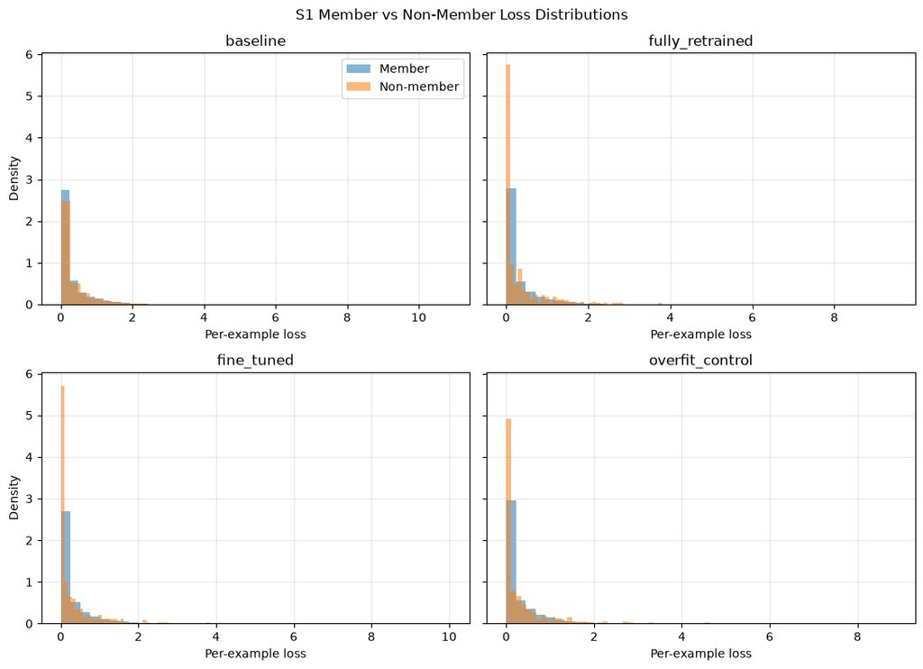

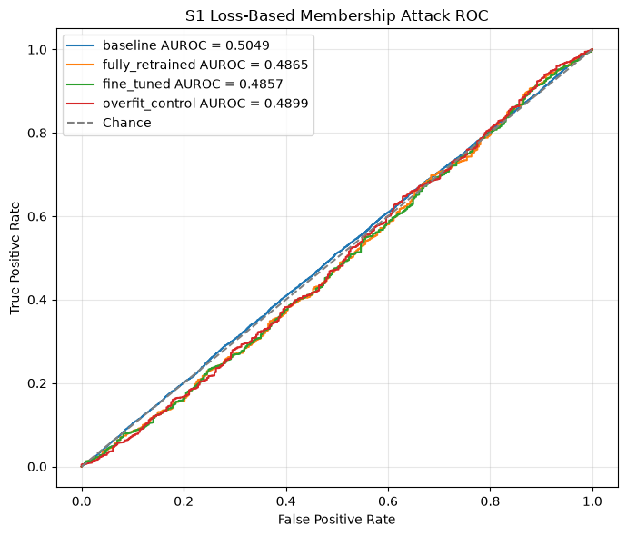

```
Saved MIA loss distribution figure to: ../../results/retain_finetuning/adult/figures/mia_v2_s1_loss_distributions.png
Saved MIA ROC figure to: ../../results/retain_finetuning/adult/figures/mia_v2_s1_loss_roc.png
```

```python
representative_scenario = "s1_random_1_percent"
representative_models = [
    "baseline",
    "fully_retrained",
    "fine_tuned",
    "overfit_control",
]

loss_distribution_fig, loss_distribution_axes = plt.subplots(
    2,
    2,
    figsize=(11, 8),
    sharey=True,
)
loss_distribution_axes = loss_distribution_axes.ravel()

for ax, model_name in zip(loss_distribution_axes, representative_models):
    score_entry = mia_score_cache[(representative_scenario, model_name)]
    member_loss = score_entry["member"]["raw_loss"]
    non_member_loss = score_entry["non_member"]["raw_loss"]

    ax.hist(
        member_loss,
        bins=40,
        alpha=0.55,
        density=True,
        label="Member",
    )
    ax.hist(
        non_member_loss,
        bins=40,
        alpha=0.55,
        density=True,
        label="Non-member",
    )
    ax.set_title(model_name)
    ax.set_xlabel("Per-example loss")
    ax.grid(alpha=0.3)

loss_distribution_axes[0].set_ylabel("Density")
loss_distribution_axes[2].set_ylabel("Density")
loss_distribution_axes[0].legend()
loss_distribution_fig.suptitle(
    "S1 Member vs Non-Member Loss Distributions"
)
loss_distribution_fig.tight_layout()
loss_distribution_path = (
    finetuning_figures_dir
    / "mia_v2_s1_loss_distributions.png"
)
loss_distribution_fig.savefig(
    loss_distribution_path,
    dpi=300,
    bbox_inches="tight",
)
plt.show()

loss_roc_fig, loss_roc_ax = plt.subplots(figsize=(7, 6))

for model_name in representative_models:
    score_entry = mia_score_cache[(representative_scenario, model_name)]
    member_scores = score_entry["member"]["loss"]
    non_member_scores = score_entry["non_member"]["loss"]
    labels = np.concatenate(
        [np.ones(len(member_scores)), np.zeros(len(non_member_scores))]
    )
    scores = np.concatenate([member_scores, non_member_scores])
    false_positive_rate, true_positive_rate, _ = roc_curve(labels, scores)
    attack_auc = roc_auc_score(labels, scores)

    loss_roc_ax.plot(
        false_positive_rate,
        true_positive_rate,
        label=f"{model_name} AUROC = {attack_auc:.4f}",
    )

loss_roc_ax.plot(
    [0, 1],
    [0, 1],
    linestyle="--",
    color="gray",
    label="Chance",
)
loss_roc_ax.set_xlabel("False Positive Rate")
loss_roc_ax.set_ylabel("True Positive Rate")
loss_roc_ax.set_title("S1 Loss-Based Membership Attack ROC")
loss_roc_ax.legend()
loss_roc_ax.grid(alpha=0.3)
loss_roc_fig.tight_layout()
loss_roc_path = finetuning_figures_dir / "mia_v2_s1_loss_roc.png"
loss_roc_fig.savefig(
    loss_roc_path,
    dpi=300,
    bbox_inches="tight",
)
plt.show()

print(f"Saved MIA loss distribution figure to: {loss_distribution_path}")
print(f"Saved MIA ROC figure to: {loss_roc_path}")
```

```python
print("Loaded evaluate_unlearning_method signature:")
print(inspect.signature(evaluate_unlearning_method))

def estimate_optimizer_steps(result):
    """Estimate optimiser steps from completed epochs and retain-set batches."""
    epochs_completed = len(result["history"]["train_loss"])
    batches_per_epoch = int(
        np.ceil(result["retain_count"] / result["batch_size"])
    )

    return epochs_completed * batches_per_epoch


def update_current_unlearning_results(new_rows, output_path, method_values):
    """Append method rows while replacing stale rows for the same method."""
    output_path.parent.mkdir(parents=True, exist_ok=True)

    if output_path.exists():
        existing_results = pd.read_csv(output_path)
        existing_results = existing_results[
            ~existing_results["method"].isin(method_values)
        ]
        combined_results = pd.concat(
            [existing_results, new_rows],
            ignore_index=True,
        )
    else:
        combined_results = new_rows.copy()

    combined_results.to_csv(output_path, index=False)

    return combined_results


def get_loss_positive_control_summary(mia_results_table):
    """Return the S1 overfit-control loss attack AUC and validity flag."""
    positive_control_rows = mia_results_table[
        (mia_results_table["scenario"] == "s1_random_1_percent")
        & (mia_results_table["model"] == "overfit_control")
        & (mia_results_table["attack_type"] == "loss")
    ]

    if positive_control_rows.empty:
        return np.nan, False

    positive_control_row = positive_control_rows.iloc[0]
    positive_control_auc = float(positive_control_row["attack_auc"])
    positive_control_ci_low = float(
        positive_control_row["attack_auc_ci_low"]
    )
    positive_control_valid = (
        positive_control_auc > 0.55
        and positive_control_ci_low > 0.5
    )

    return positive_control_auc, positive_control_valid
```

```
Loaded evaluate_unlearning_method signature:
(original_model: 'torch.nn.Module', unlearned_model: 'PredictionSource', retrained_model: 'torch.nn.Module', X_retain: 'pd.DataFrame', y_retain: 'pd.Series', X_forget: 'pd.DataFrame', y_forget: 'pd.Series', X_test: 'pd.DataFrame', y_test: 'pd.Series', scenario_name: 'str', method_name: 'str', runtim…
```

## 7.3 Confidence-Based Membership Inference

Confidence-based membership inference uses the model’s prediction confidence as the attack signal. If the model is consistently more confident on member records than on non-member records, an attacker may be able to infer whether a record was used during training. This section reports attack AUROC, confidence intervals, low-false-positive-rate performance and supporting statistics for all available deletion scenarios.

```python
mia_confidence_results = mia_results_v2[
    mia_results_v2["attack_type"].str.contains(
        "confidence",
        case=False,
        na=False,
    )
].reset_index(drop=True)

mia_confidence_results
```

|  | scenario | model | attack_type | member_set | non_member_set | attack_auc | attack_auc_ci_low | attack_auc_ci_high | tpr_at_fpr_0.001 | tpr_at_fpr_0.01 | tpr_at_fpr_0.05 | permutation_p_value | mean_member_score | mean_non_member_score | attack_auc_bootstrap_mean | threshold_balanced_attack_accuracy | attack_threshold | member_count | non_member_count |
| --- | --- | --- | --- | --- | --- | --- | --- | --- | --- | --- | --- | --- | --- | --- | --- | --- | --- | --- | --- |
| 0 | s1_random_1_percent | baseline | confidence | train | test | 0.504910 | 0.497358 | 0.513014 | 0.000000 | 0.008541 | 0.048905 | 0.115 | 0.805364 | 0.800279 | 0.504633 | 0.502382 | 0.993145 | 34189 | 7327 |
| 1 | s1_random_1_percent | fully_retrained | confidence | retain | forget | 0.486451 | 0.455818 | 0.515754 | 0.000000 | 0.009868 | 0.040594 | 0.830 | 0.806945 | 0.805059 | 0.486693 | 0.485982 | 0.993517 | 33847 | 342 |
| 2 | s1_random_1_percent | fine_tuned | confidence | retain | forget | 0.485686 | 0.455382 | 0.523086 | 0.000000 | 0.012881 | 0.042219 | 0.735 | 0.807504 | 0.807117 | 0.486263 | 0.484505 | 0.993896 | 33847 | 342 |
| 3 | s1_random_1_percent | overfit_control | confidence | retain | forget | 0.489905 | 0.456763 | 0.519361 | 0.005259 | 0.007209 | 0.032381 | 0.745 | 0.812671 | 0.805082 | 0.489216 | 0.484505 | 0.995132 | 33847 | 342 |
| 4 | s2_random_5_percent | baseline | confidence | train | test | 0.504910 | 0.497358 | 0.513014 | 0.000000 | 0.008541 | 0.048905 | 0.115 | 0.805364 | 0.800279 | 0.504633 | 0.502382 | 0.993145 | 34189 | 7327 |
| 5 | s2_random_5_percent | fully_retrained | confidence | retain | forget | 0.504221 | 0.491837 | 0.516797 | 0.000000 | 0.009760 | 0.054310 | 0.300 | 0.804412 | 0.800965 | 0.503986 | 0.502244 | 0.993226 | 32480 | 1709 |
| 6 | s2_random_5_percent | fine_tuned | confidence | retain | forget | 0.502299 | 0.488162 | 0.514738 | 0.000000 | 0.009729 | 0.048953 | 0.385 | 0.806184 | 0.805624 | 0.502551 | 0.502552 | 0.993362 | 32480 | 1709 |
| 7 | s3_simulated_data_provider_withdrawal | baseline | confidence | train | test | 0.504910 | 0.497358 | 0.513014 | 0.000000 | 0.008541 | 0.048905 | 0.115 | 0.805364 | 0.800279 | 0.504633 | 0.502382 | 0.993145 | 34189 | 7327 |
| 8 | s3_simulated_data_provider_withdrawal | fully_retrained | confidence | retain | forget | 0.505529 | 0.491121 | 0.518876 | 0.000000 | 0.009510 | 0.046505 | 0.180 | 0.807199 | 0.802418 | 0.505514 | 0.506364 | 0.993931 | 32491 | 1698 |
| 9 | s3_simulated_data_provider_withdrawal | fine_tuned | confidence | retain | forget | 0.505987 | 0.492105 | 0.518908 | 0.000000 | 0.010957 | 0.044197 | 0.200 | 0.808644 | 0.803124 | 0.506121 | 0.505744 | 0.994425 | 32491 | 1698 |
| 10 | s4_random_10_percent | baseline | confidence | train | test | 0.504910 | 0.497358 | 0.513014 | 0.000000 | 0.008541 | 0.048905 | 0.115 | 0.805364 | 0.800279 | 0.504633 | 0.502382 | 0.993145 | 34189 | 7327 |
| 11 | s4_random_10_percent | fully_retrained | confidence | retain | forget | 0.499517 | 0.489415 | 0.509078 | 0.000000 | 0.013747 | 0.051999 | 0.520 | 0.807368 | 0.805069 | 0.499540 | 0.497047 | 0.993535 | 30770 | 3419 |
| 12 | s4_random_10_percent | fine_tuned | confidence | retain | forget | 0.498368 | 0.487395 | 0.508652 | 0.000000 | 0.013422 | 0.049366 | 0.660 | 0.806043 | 0.805230 | 0.498121 | 0.497372 | 0.994051 | 30770 | 3419 |
| 13 | s5_retention_expiry | baseline | confidence | train | test | 0.504910 | 0.497358 | 0.513014 | 0.000000 | 0.008541 | 0.048905 | 0.115 | 0.805364 | 0.800279 | 0.504633 | 0.502382 | 0.993145 | 34189 | 7327 |
| 14 | s5_retention_expiry | fully_retrained | confidence | retain | forget | 0.593076 | 0.585421 | 0.601110 | 0.000000 | 0.019857 | 0.111383 | 0.000 | 0.815689 | 0.750027 | 0.593417 | 0.557716 | 0.993563 | 28604 | 5585 |
| 15 | s5_retention_expiry | fine_tuned | confidence | retain | forget | 0.595936 | 0.589561 | 0.603192 | 0.000000 | 0.021570 | 0.123864 | 0.000 | 0.816131 | 0.755987 | 0.596074 | 0.563066 | 0.993836 | 28604 | 5585 |

## 7.4 Loss-Based Membership Inference

Loss-based membership inference uses per-record prediction loss as the attack signal. Training records may receive lower loss because the model has fitted them more closely, allowing an attacker to distinguish members from non-members. This is treated as the primary membership-inference diagnostic in the notebook because loss directly measures how closely the model fits each individual record.

```python
mia_loss_results = mia_results_v2[
    mia_results_v2["attack_type"].str.contains(
        "loss",
        case=False,
        na=False,
    )
].reset_index(drop=True)

mia_loss_results
```

|  | scenario | model | attack_type | member_set | non_member_set | attack_auc | attack_auc_ci_low | attack_auc_ci_high | tpr_at_fpr_0.001 | tpr_at_fpr_0.01 | tpr_at_fpr_0.05 | permutation_p_value | mean_member_score | mean_non_member_score | attack_auc_bootstrap_mean | threshold_balanced_attack_accuracy | attack_threshold | member_count | non_member_count |
| --- | --- | --- | --- | --- | --- | --- | --- | --- | --- | --- | --- | --- | --- | --- | --- | --- | --- | --- | --- |
| 0 | s1_random_1_percent | baseline | loss | train | test | 0.504910 | 0.497760 | 0.511849 | 0.000000 | 0.008044 | 0.048875 | 0.100 | -0.298928 | -0.312553 | 0.505224 | 0.502382 | -0.006879 | 34189 | 7327 |
| 1 | s1_random_1_percent | fully_retrained | loss | retain | forget | 0.486451 | 0.458560 | 0.514172 | 0.000000 | 0.009838 | 0.040535 | 0.865 | -0.299450 | -0.314262 | 0.485803 | 0.485982 | -0.006504 | 33847 | 342 |
| 2 | s1_random_1_percent | fine_tuned | loss | retain | forget | 0.485688 | 0.454531 | 0.517037 | 0.000000 | 0.012763 | 0.042219 | 0.835 | -0.297058 | -0.307192 | 0.486760 | 0.484505 | -0.006123 | 33847 | 342 |
| 3 | s1_random_1_percent | overfit_control | loss | retain | forget | 0.489902 | 0.461581 | 0.522862 | 0.004757 | 0.006795 | 0.031938 | 0.805 | -0.285870 | -0.320002 | 0.490429 | 0.484505 | -0.004880 | 33847 | 342 |
| 4 | s2_random_5_percent | baseline | loss | train | test | 0.504910 | 0.497760 | 0.511849 | 0.000000 | 0.008044 | 0.048875 | 0.100 | -0.298928 | -0.312553 | 0.505224 | 0.502382 | -0.006879 | 34189 | 7327 |
| 5 | s2_random_5_percent | fully_retrained | loss | retain | forget | 0.504221 | 0.489819 | 0.516724 | 0.000000 | 0.009606 | 0.054156 | 0.250 | -0.298126 | -0.302795 | 0.503619 | 0.502244 | -0.006796 | 32480 | 1709 |
| 6 | s2_random_5_percent | fine_tuned | loss | retain | forget | 0.502299 | 0.487694 | 0.517233 | 0.000000 | 0.009575 | 0.048892 | 0.340 | -0.297956 | -0.294836 | 0.502587 | 0.502552 | -0.006660 | 32480 | 1709 |
| 7 | s3_simulated_data_provider_withdrawal | baseline | loss | train | test | 0.504910 | 0.497760 | 0.511849 | 0.000000 | 0.008044 | 0.048875 | 0.100 | -0.298928 | -0.312553 | 0.505224 | 0.502382 | -0.006879 | 34189 | 7327 |
| 8 | s3_simulated_data_provider_withdrawal | fully_retrained | loss | retain | forget | 0.505528 | 0.492898 | 0.517942 | 0.000000 | 0.009356 | 0.046505 | 0.195 | -0.300133 | -0.309671 | 0.505417 | 0.506364 | -0.006088 | 32491 | 1698 |
| 9 | s3_simulated_data_provider_withdrawal | fine_tuned | loss | retain | forget | 0.505985 | 0.493356 | 0.519059 | 0.000000 | 0.010403 | 0.044043 | 0.175 | -0.295506 | -0.305458 | 0.505981 | 0.505759 | -0.005590 | 32491 | 1698 |
| 10 | s4_random_10_percent | baseline | loss | train | test | 0.504910 | 0.497760 | 0.511849 | 0.000000 | 0.008044 | 0.048875 | 0.100 | -0.298928 | -0.312553 | 0.505224 | 0.502382 | -0.006879 | 34189 | 7327 |
| 11 | s4_random_10_percent | fully_retrained | loss | retain | forget | 0.499516 | 0.488983 | 0.508140 | 0.000000 | 0.013455 | 0.051999 | 0.500 | -0.299056 | -0.308096 | 0.498927 | 0.497047 | -0.006486 | 30770 | 3419 |
| 12 | s4_random_10_percent | fine_tuned | loss | retain | forget | 0.498367 | 0.488951 | 0.507533 | 0.000000 | 0.013162 | 0.049171 | 0.640 | -0.296402 | -0.301193 | 0.497929 | 0.497372 | -0.005967 | 30770 | 3419 |
| 13 | s5_retention_expiry | baseline | loss | train | test | 0.504910 | 0.497760 | 0.511849 | 0.000000 | 0.008044 | 0.048875 | 0.100 | -0.298928 | -0.312553 | 0.505224 | 0.502382 | -0.006879 | 34189 | 7327 |
| 14 | s5_retention_expiry | fully_retrained | loss | retain | forget | 0.593077 | 0.585185 | 0.601347 | 0.000000 | 0.019787 | 0.111383 | 0.000 | -0.281678 | -0.405616 | 0.593278 | 0.557716 | -0.006458 | 28604 | 5585 |
| 15 | s5_retention_expiry | fine_tuned | loss | retain | forget | 0.595937 | 0.589050 | 0.603954 | 0.000000 | 0.021361 | 0.123864 | 0.000 | -0.282281 | -0.382893 | 0.596048 | 0.563066 | -0.006183 | 28604 | 5585 |

## 7.5 Low False-Positive-Rate Metrics

This section reports the true-positive rate achieved by each membership-inference attack when the permitted false-positive rate is limited to 0.1%, 1% and 5%. These stricter operating points show whether the attack remains useful when only a small number of non-member records may be incorrectly classified as members.

```python
mia_low_fpr_summary = mia_results_v2[
    [
        "scenario",
        "model",
        "attack_type",
        "tpr_at_fpr_0.001",
        "tpr_at_fpr_0.01",
        "tpr_at_fpr_0.05",
    ]
].copy()

mia_low_fpr_summary
```

|  | scenario | model | attack_type | tpr_at_fpr_0.001 | tpr_at_fpr_0.01 | tpr_at_fpr_0.05 |
| --- | --- | --- | --- | --- | --- | --- |
| 0 | s1_random_1_percent | baseline | confidence | 0.000000 | 0.008541 | 0.048905 |
| 1 | s1_random_1_percent | baseline | loss | 0.000000 | 0.008044 | 0.048875 |
| 2 | s1_random_1_percent | fully_retrained | confidence | 0.000000 | 0.009868 | 0.040594 |
| 3 | s1_random_1_percent | fully_retrained | loss | 0.000000 | 0.009838 | 0.040535 |
| 4 | s1_random_1_percent | fine_tuned | confidence | 0.000000 | 0.012881 | 0.042219 |
| 5 | s1_random_1_percent | fine_tuned | loss | 0.000000 | 0.012763 | 0.042219 |
| 6 | s1_random_1_percent | overfit_control | confidence | 0.005259 | 0.007209 | 0.032381 |
| 7 | s1_random_1_percent | overfit_control | loss | 0.004757 | 0.006795 | 0.031938 |
| 8 | s2_random_5_percent | baseline | confidence | 0.000000 | 0.008541 | 0.048905 |
| 9 | s2_random_5_percent | baseline | loss | 0.000000 | 0.008044 | 0.048875 |
| 10 | s2_random_5_percent | fully_retrained | confidence | 0.000000 | 0.009760 | 0.054310 |
| 11 | s2_random_5_percent | fully_retrained | loss | 0.000000 | 0.009606 | 0.054156 |
| 12 | s2_random_5_percent | fine_tuned | confidence | 0.000000 | 0.009729 | 0.048953 |
| 13 | s2_random_5_percent | fine_tuned | loss | 0.000000 | 0.009575 | 0.048892 |
| 14 | s3_simulated_data_provider_withdrawal | baseline | confidence | 0.000000 | 0.008541 | 0.048905 |
| 15 | s3_simulated_data_provider_withdrawal | baseline | loss | 0.000000 | 0.008044 | 0.048875 |
| 16 | s3_simulated_data_provider_withdrawal | fully_retrained | confidence | 0.000000 | 0.009510 | 0.046505 |
| 17 | s3_simulated_data_provider_withdrawal | fully_retrained | loss | 0.000000 | 0.009356 | 0.046505 |
| 18 | s3_simulated_data_provider_withdrawal | fine_tuned | confidence | 0.000000 | 0.010957 | 0.044197 |
| 19 | s3_simulated_data_provider_withdrawal | fine_tuned | loss | 0.000000 | 0.010403 | 0.044043 |
| 20 | s4_random_10_percent | baseline | confidence | 0.000000 | 0.008541 | 0.048905 |
| 21 | s4_random_10_percent | baseline | loss | 0.000000 | 0.008044 | 0.048875 |
| 22 | s4_random_10_percent | fully_retrained | confidence | 0.000000 | 0.013747 | 0.051999 |
| 23 | s4_random_10_percent | fully_retrained | loss | 0.000000 | 0.013455 | 0.051999 |
| 24 | s4_random_10_percent | fine_tuned | confidence | 0.000000 | 0.013422 | 0.049366 |
| 25 | s4_random_10_percent | fine_tuned | loss | 0.000000 | 0.013162 | 0.049171 |
| 26 | s5_retention_expiry | baseline | confidence | 0.000000 | 0.008541 | 0.048905 |
| 27 | s5_retention_expiry | baseline | loss | 0.000000 | 0.008044 | 0.048875 |
| 28 | s5_retention_expiry | fully_retrained | confidence | 0.000000 | 0.019857 | 0.111383 |
| 29 | s5_retention_expiry | fully_retrained | loss | 0.000000 | 0.019787 | 0.111383 |
| 30 | s5_retention_expiry | fine_tuned | confidence | 0.000000 | 0.021570 | 0.123864 |
| 31 | s5_retention_expiry | fine_tuned | loss | 0.000000 | 0.021361 | 0.123864 |

## 7.6 Statistical Validation

This section reports confidence intervals, bootstrap estimates and permutation-test results for each membership-inference attack. These statistical checks indicate whether an observed attack AUROC is reliably different from chance or could be explained by sampling variation.

```python
mia_statistical_validation = mia_results_v2[
    [
        "scenario",
        "model",
        "attack_type",
        "attack_auc",
        "attack_auc_ci_low",
        "attack_auc_ci_high",
        "permutation_p_value",
        "attack_auc_bootstrap_mean",
    ]
].copy()

mia_statistical_validation
```

|  | scenario | model | attack_type | attack_auc | attack_auc_ci_low | attack_auc_ci_high | permutation_p_value | attack_auc_bootstrap_mean |
| --- | --- | --- | --- | --- | --- | --- | --- | --- |
| 0 | s1_random_1_percent | baseline | confidence | 0.504910 | 0.497358 | 0.513014 | 0.115 | 0.504633 |
| 1 | s1_random_1_percent | baseline | loss | 0.504910 | 0.497760 | 0.511849 | 0.100 | 0.505224 |
| 2 | s1_random_1_percent | fully_retrained | confidence | 0.486451 | 0.455818 | 0.515754 | 0.830 | 0.486693 |
| 3 | s1_random_1_percent | fully_retrained | loss | 0.486451 | 0.458560 | 0.514172 | 0.865 | 0.485803 |
| 4 | s1_random_1_percent | fine_tuned | confidence | 0.485686 | 0.455382 | 0.523086 | 0.735 | 0.486263 |
| 5 | s1_random_1_percent | fine_tuned | loss | 0.485688 | 0.454531 | 0.517037 | 0.835 | 0.486760 |
| 6 | s1_random_1_percent | overfit_control | confidence | 0.489905 | 0.456763 | 0.519361 | 0.745 | 0.489216 |
| 7 | s1_random_1_percent | overfit_control | loss | 0.489902 | 0.461581 | 0.522862 | 0.805 | 0.490429 |
| 8 | s2_random_5_percent | baseline | confidence | 0.504910 | 0.497358 | 0.513014 | 0.115 | 0.504633 |
| 9 | s2_random_5_percent | baseline | loss | 0.504910 | 0.497760 | 0.511849 | 0.100 | 0.505224 |
| 10 | s2_random_5_percent | fully_retrained | confidence | 0.504221 | 0.491837 | 0.516797 | 0.300 | 0.503986 |
| 11 | s2_random_5_percent | fully_retrained | loss | 0.504221 | 0.489819 | 0.516724 | 0.250 | 0.503619 |
| 12 | s2_random_5_percent | fine_tuned | confidence | 0.502299 | 0.488162 | 0.514738 | 0.385 | 0.502551 |
| 13 | s2_random_5_percent | fine_tuned | loss | 0.502299 | 0.487694 | 0.517233 | 0.340 | 0.502587 |
| 14 | s3_simulated_data_provider_withdrawal | baseline | confidence | 0.504910 | 0.497358 | 0.513014 | 0.115 | 0.504633 |
| 15 | s3_simulated_data_provider_withdrawal | baseline | loss | 0.504910 | 0.497760 | 0.511849 | 0.100 | 0.505224 |
| 16 | s3_simulated_data_provider_withdrawal | fully_retrained | confidence | 0.505529 | 0.491121 | 0.518876 | 0.180 | 0.505514 |
| 17 | s3_simulated_data_provider_withdrawal | fully_retrained | loss | 0.505528 | 0.492898 | 0.517942 | 0.195 | 0.505417 |
| 18 | s3_simulated_data_provider_withdrawal | fine_tuned | confidence | 0.505987 | 0.492105 | 0.518908 | 0.200 | 0.506121 |
| 19 | s3_simulated_data_provider_withdrawal | fine_tuned | loss | 0.505985 | 0.493356 | 0.519059 | 0.175 | 0.505981 |
| 20 | s4_random_10_percent | baseline | confidence | 0.504910 | 0.497358 | 0.513014 | 0.115 | 0.504633 |
| 21 | s4_random_10_percent | baseline | loss | 0.504910 | 0.497760 | 0.511849 | 0.100 | 0.505224 |
| 22 | s4_random_10_percent | fully_retrained | confidence | 0.499517 | 0.489415 | 0.509078 | 0.520 | 0.499540 |
| 23 | s4_random_10_percent | fully_retrained | loss | 0.499516 | 0.488983 | 0.508140 | 0.500 | 0.498927 |
| 24 | s4_random_10_percent | fine_tuned | confidence | 0.498368 | 0.487395 | 0.508652 | 0.660 | 0.498121 |
| 25 | s4_random_10_percent | fine_tuned | loss | 0.498367 | 0.488951 | 0.507533 | 0.640 | 0.497929 |
| 26 | s5_retention_expiry | baseline | confidence | 0.504910 | 0.497358 | 0.513014 | 0.115 | 0.504633 |
| 27 | s5_retention_expiry | baseline | loss | 0.504910 | 0.497760 | 0.511849 | 0.100 | 0.505224 |
| 28 | s5_retention_expiry | fully_retrained | confidence | 0.593076 | 0.585421 | 0.601110 | 0.000 | 0.593417 |
| 29 | s5_retention_expiry | fully_retrained | loss | 0.593077 | 0.585185 | 0.601347 | 0.000 | 0.593278 |
| 30 | s5_retention_expiry | fine_tuned | confidence | 0.595936 | 0.589561 | 0.603192 | 0.000 | 0.596074 |
| 31 | s5_retention_expiry | fine_tuned | loss | 0.595937 | 0.589050 | 0.603954 | 0.000 | 0.596048 |

## 7.7 Positive-Control Assessment

This section tests whether the membership-inference method can detect membership in the deliberately overfitted control model. A valid positive control would demonstrate that the attack is capable of identifying a known membership signal. Because the positive control does not exceed the required AUROC and confidence-interval thresholds, the membership-inference results must be treated as inconclusive rather than as evidence of successful forgetting.

```python
positive_control_auc, positive_control_valid = (
    get_loss_positive_control_summary(mia_results_v2)
)
print(
    "Loss-based MIA positive-control AUROC: "
    f"{positive_control_auc:.4f} | valid={positive_control_valid}"
)
```

```
Loss-based MIA positive-control AUROC: 0.4899 | valid=False
```

## 7.8 Forgetfulness Evaluation Summary

This section brings together three separate forms of forgetfulness evidence. Entropy measures model uncertainty on the forget records, membership inference measures whether membership is detectable, and the shared evaluator reports other forget-set similarity measurements against the fully retrained reference. These diagnostics are related but distinct empirical measurements, and none of them proves formal deletion on its own.

```python
retain_finetuning_evaluation_rows = []
retain_finetuning_forget_detail_frames = []

for scenario in scenario_names:
    evaluation_row, detail_tables = evaluate_unlearning_method(
        original_model=baseline_model,
        unlearned_model=finetuned_results[scenario]["model"],
        retrained_model=retrained_models[scenario],
        X_retain=X_train_processed.loc[retain_indices[scenario]],
        y_retain=y_train.loc[retain_indices[scenario]],
        X_forget=X_train_processed.loc[forget_indices[scenario]],
        y_forget=y_train.loc[forget_indices[scenario]],
        X_test=X_test_processed,
        y_test=y_test,
        scenario_name=scenario,
        method_name="retain_finetuning",
        runtime=finetuned_results[scenario]["runtime_seconds"],
        optimizer_steps=estimate_optimizer_steps(
            finetuned_results[scenario]
        ),
        random_seed=RANDOM_SEED,
        mia_positive_control_auc=positive_control_auc,
        mia_positive_control_valid=positive_control_valid,
        return_details=True,
    )

    retain_finetuning_evaluation_rows.append(evaluation_row)
    retain_finetuning_forget_detail_frames.extend(
        [
            detail_tables["forget_unlearned"],
            detail_tables["forget_retrained"],
            detail_tables["forget_original"],
        ]
    )

retain_finetuning_unlearning_evaluation = pd.concat(
    retain_finetuning_evaluation_rows,
    ignore_index=True,
)
retain_finetuning_forget_details = pd.concat(
    retain_finetuning_forget_detail_frames,
    ignore_index=True,
)
```

**Build shared evaluation tables** The shared evaluation output is divided into two reader-facing tables. The utility table reports test-set performance, similarity to full retraining and computational cost. The forget-set fidelity table reports how closely the fine-tuned model matches the fully retrained model on deleted records using distributional distances, prediction differences, agreement rates and membership-inference results.

```python
retain_finetuning_utility_table = retain_finetuning_unlearning_evaluation[
    [
        "scenario",
        "method",
        "test_accuracy",
        "test_recall",
        "test_f1",
        "test_auroc",
        "test_loss",
        "delta_accuracy",
        "delta_recall",
        "delta_f1",
        "delta_auroc",
        "delta_test_loss",
        "test_agreement_retrain",
        "test_probability_mad",
        "runtime_seconds",
        "optimizer_steps",
    ]
]
retain_finetuning_forget_set_fidelity_table = (
    retain_finetuning_unlearning_evaluation[
        [
            "scenario",
            "method",
            "forget_size",
            "forget_percentage",
            "forget_ks_statistic",
            "forget_ks_pvalue",
            "forget_wasserstein",
            "forget_mean_loss_gap",
            "forget_probability_mad",
            "forget_agreement_retrain",
            "original_retrain_forget_ks",
            "original_retrain_forget_wasserstein",
            "mia_auroc",
            "mia_attack_advantage",
            "mia_auc_ci_low",
            "mia_auc_ci_high",
            "mia_positive_control_auc",
            "mia_positive_control_valid",
            "mia_interpretation",
        ]
    ]
)
```

**Save shared evaluation outputs**

This subsection saves the shared evaluation results for later analysis and cross-method comparison. Existing retain-set fine-tuning rows are replaced before the new results are added, preventing outdated results from remaining in the combined evaluation file. Record-level forget-set outputs are also saved for later statistical analysis and plotting.

```python
current_evaluation_path = Path("../../results/unlearning_evaluation_current.csv")
current_unlearning_evaluation = update_current_unlearning_results(
    new_rows=retain_finetuning_unlearning_evaluation,
    output_path=current_evaluation_path,
    method_values=["retain_finetuning"],
)
retain_finetuning_unlearning_evaluation_path = (
    finetuning_metrics_dir / "unlearning_evaluation.csv"
)
retain_finetuning_forget_details_path = (
    finetuning_tables_dir / "forget_record_evaluation.csv"
)
retain_finetuning_unlearning_evaluation.to_csv(
    retain_finetuning_unlearning_evaluation_path,
    index=False,
)
retain_finetuning_forget_details.to_csv(
    retain_finetuning_forget_details_path,
    index=False,
)
```

**Display shared evaluation outputs**

This subsection displays the utility and forget-set fidelity tables produced by the shared evaluator. The tables make the selected retain-set fine-tuning results available for direct review before they are compared with other unlearning methods.

```python
print(
    "Saved retain-set fine-tuning shared evaluation to: "
    f"{retain_finetuning_unlearning_evaluation_path}"
)
print(f"Updated current unlearning evaluation: {current_evaluation_path}")

display(retain_finetuning_utility_table)
retain_finetuning_forget_set_fidelity_table
```

```
Saved retain-set fine-tuning shared evaluation to: ../../results/retain_finetuning/adult/metrics/unlearning_evaluation.csv
Updated current unlearning evaluation: ../../results/unlearning_evaluation_current.csv
```

|  | scenario | method | test_accuracy | test_recall | test_f1 | test_auroc | test_loss | delta_accuracy | delta_recall | delta_f1 | delta_auroc | delta_test_loss | test_agreement_retrain | test_probability_mad | runtime_seconds | optimizer_steps |
| --- | --- | --- | --- | --- | --- | --- | --- | --- | --- | --- | --- | --- | --- | --- | --- | --- |
| 0 | s1_random_1_percent | retain_finetuning | 0.858332 | 0.618369 | 0.676232 | 0.909771 | 0.312304 | 0.000546 | -0.003423 | -0.000366 | -0.000085 | 0.000222 | 0.989900 | 0.010496 | 7.865476 | 3174 |
| 1 | s2_random_5_percent | retain_finetuning | 0.856012 | 0.619509 | 0.673071 | 0.909598 | 0.312609 | -0.000409 | -0.006275 | -0.002838 | 0.000239 | -0.000381 | 0.983486 | 0.011196 | 6.137233 | 2540 |
| 2 | s3_simulated_data_provider_withdrawal | retain_finetuning | 0.857650 | 0.626355 | 0.677987 | 0.909919 | 0.312227 | 0.001638 | 0.021107 | 0.010061 | -0.000224 | 0.000397 | 0.985533 | 0.013767 | 10.816388 | 4064 |
| 3 | s4_random_10_percent | retain_finetuning | 0.857513 | 0.627496 | 0.678175 | 0.909673 | 0.312524 | 0.002047 | 0.003423 | 0.004322 | 0.000235 | -0.000232 | 0.986488 | 0.015660 | 8.601153 | 3367 |
| 4 | s5_retention_expiry | retain_finetuning | 0.857240 | 0.621791 | 0.675759 | 0.909646 | 0.312618 | 0.000955 | 0.018825 | 0.008251 | 0.001210 | -0.001669 | 0.985669 | 0.013607 | 5.558269 | 2235 |

|  | scenario | method | forget_size | forget_percentage | forget_ks_statistic | forget_ks_pvalue | forget_wasserstein | forget_mean_loss_gap | forget_probability_mad | forget_agreement_retrain | original_retrain_forget_ks | original_retrain_forget_wasserstein | mia_auroc | mia_attack_advantage | mia_auc_ci_low | mia_auc_ci_high | mia_positive_control_auc | mia_positive_control_valid | mia_interpretation |
| --- | --- | --- | --- | --- | --- | --- | --- | --- | --- | --- | --- | --- | --- | --- | --- | --- | --- | --- | --- |
| 0 | s1_random_1_percent | retain_finetuning | 342 | 0.010003 | 0.029240 | 0.998630 | 0.010665 | 0.007070 | 0.011010 | 0.988304 | 0.035088 | 0.015112 | 0.492493 | 0.015013 | 0.454031 | 0.533080 | 0.489902 | False | inconclusive |
| 1 | s2_random_5_percent | retain_finetuning | 1709 | 0.049987 | 0.015799 | 0.983361 | 0.009710 | 0.007960 | 0.011669 | 0.986542 | 0.015214 | 0.008622 | 0.505909 | 0.011818 | 0.489266 | 0.525269 | 0.489902 | False | inconclusive |
| 2 | s3_simulated_data_provider_withdrawal | retain_finetuning | 1698 | 0.049665 | 0.021790 | 0.815115 | 0.007488 | 0.004213 | 0.014124 | 0.987044 | 0.020612 | 0.013181 | 0.498099 | 0.003802 | 0.479337 | 0.517033 | 0.489902 | False | inconclusive |
| 3 | s4_random_10_percent | retain_finetuning | 3419 | 0.100003 | 0.015502 | 0.805991 | 0.013696 | 0.006903 | 0.015063 | 0.983621 | 0.011992 | 0.014658 | 0.502188 | 0.004376 | 0.489779 | 0.513932 | 0.489902 | False | inconclusive |
| 4 | s5_retention_expiry | retain_finetuning | 5585 | 0.163357 | 0.021307 | 0.158365 | 0.026614 | 0.022723 | 0.027758 | 0.960430 | 0.035452 | 0.038243 | 0.594357 | 0.188714 | 0.584673 | 0.604007 | 0.489902 | False | inconclusive |

**Shared evaluation plots**

These plots visualise the main shared-evaluation results. The forget-loss ECDF compares the fine-tuned and fully retrained loss distributions on deleted records. The utility-difference plot shows changes in test F1, while the forget-set fidelity plot compares Wasserstein distance across scenarios. The runtime-versus-fidelity plot illustrates the trade-off between computational efficiency and similarity to full retraining.

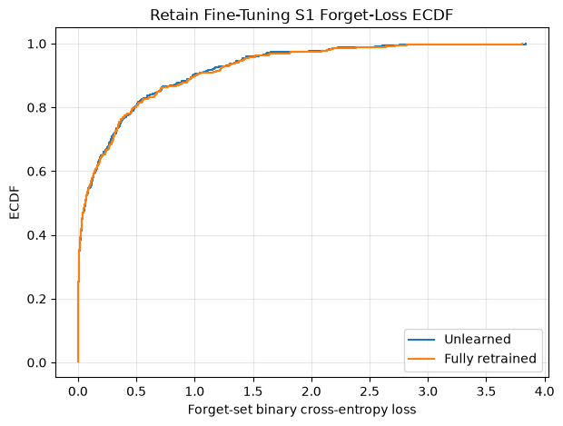

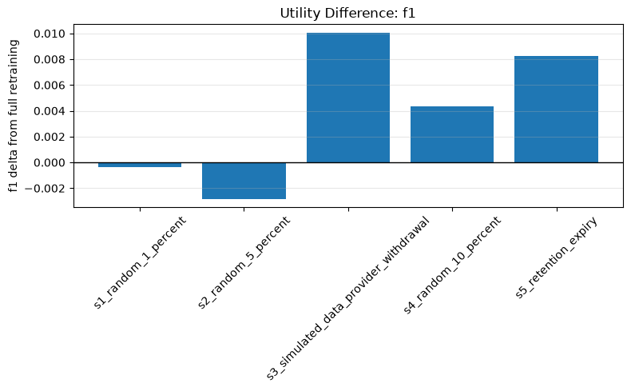

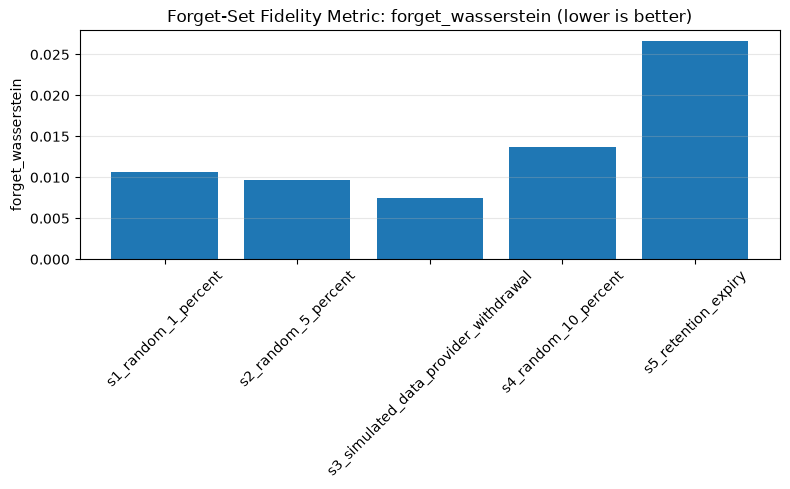

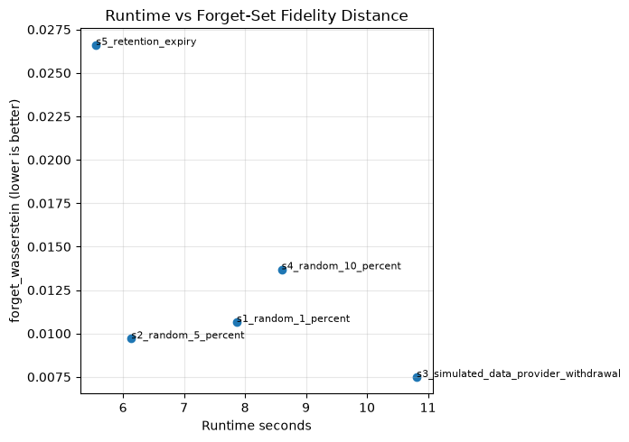

```
Saved shared evaluation plots to: ../../results/retain_finetuning/adult/figures
```

```python
representative_scenario = "s1_random_1_percent"
representative_unlearned = retain_finetuning_forget_details[
    (retain_finetuning_forget_details["scenario"] == representative_scenario)
    & (retain_finetuning_forget_details["model"] == "retain_finetuning")
]
representative_retrained = retain_finetuning_forget_details[
    (retain_finetuning_forget_details["scenario"] == representative_scenario)
    & (retain_finetuning_forget_details["model"] == "fully_retrained")
]

forget_ecdf_fig, _ = plot_forget_loss_ecdf(
    forget_unlearned=representative_unlearned,
    forget_retrained=representative_retrained,
    title="Retain Fine-Tuning S1 Forget-Loss ECDF",
)
utility_delta_fig, _ = plot_utility_delta(
    retain_finetuning_unlearning_evaluation,
    metric="f1",
)
forget_set_fidelity_fig, _ = plot_forget_set_fidelity(
    retain_finetuning_unlearning_evaluation,
    metric="forget_wasserstein",
)
runtime_fidelity_fig, _ = plot_runtime_vs_forget_set_fidelity(
    retain_finetuning_unlearning_evaluation,
    fidelity_metric="forget_wasserstein",
)

shared_plot_specs = [
    (forget_ecdf_fig, "shared_eval_forget_loss_ecdf_s1.png"),
    (utility_delta_fig, "shared_eval_utility_delta_f1.png"),
    (forget_set_fidelity_fig, "shared_eval_forget_wasserstein.png"),
    (runtime_fidelity_fig, "shared_eval_runtime_vs_forget_wasserstein.png"),
]

for fig, filename in shared_plot_specs:
    fig.savefig(
        finetuning_figures_dir / filename,
        dpi=300,
        bbox_inches="tight",
    )
    plt.show()

print(f"Saved shared evaluation plots to: {finetuning_figures_dir}")
```

**Summary**

Membership-inference results for retain-set fine-tuning are near chance across all five scenarios (loss-based AUROC 0.4857–0.5960), with S5 the only scenario showing elevation above 0.5 — and that elevation appears identically in the fully retrained reference, indicating it reflects S5's distributional construction rather than membership leakage. However, none of these results can be interpreted as evidence of successful forgetting, because the attack's own positive control — a model deliberately trained to maximise memorisation — only achieves AUROC 0.4899, failing the validity threshold required to trust the attack's output. Accordingly, all five scenarios are marked inconclusive in the shared evaluation table. A secondary, attack-independent measure of forget-set similarity (Wasserstein distance to the fully retrained model) shows fine-tuning moving closer to the retraining reference than the untouched baseline in four of five scenarios, with S2 the sole exception. Membership-inference and distributional-similarity evidence should therefore be read as separate lines of evidence: the former is inconclusive by construction in this notebook, while the latter offers modest, scenario-dependent support for behavioural similarity to full retraining.

# 8. Computational Evaluation

Computational evaluation compares the runtime of retain-set fine-tuning with full retraining. This section focuses on the cost of each method rather than predictive behaviour.

## 8.1 Fine-Tuning Runtime

The fine-tuning runtime table records how long retain-set fine-tuning took for each deletion scenario. These values are used as the approximate method runtime in the later comparison.

```python
finetuning_runtime_display = finetuning_runtime_summary.copy()

finetuning_runtime_display = finetuning_runtime_display.rename(
    columns={"num_epochs": "configured_max_epochs"}
)

finetuning_runtime_display["actual_epochs_run"] = (
    finetuning_runtime_display["scenario"].map(
        {
            scenario: len(result["history"]["train_loss"])
            for scenario, result in finetuned_results.items()
        }
    )
)

finetuning_runtime_display
```

|  | scenario | retain_count | configured_max_epochs | batch_size | learning_rate | best_epoch | best_val_loss | early_stopping_triggered | runtime_seconds | actual_epochs_run |
| --- | --- | --- | --- | --- | --- | --- | --- | --- | --- | --- |
| 0 | s1_random_1_percent | 33847 | 10 | 64 | 0.0005 | 2 | 0.301200 | True | 7.865476 | 6 |
| 1 | s2_random_5_percent | 32480 | 10 | 64 | 0.0005 | 1 | 0.300663 | True | 6.137233 | 5 |
| 2 | s3_simulated_data_provider_withdrawal | 32491 | 10 | 64 | 0.0005 | 4 | 0.300598 | True | 10.816388 | 8 |
| 3 | s4_random_10_percent | 30770 | 10 | 64 | 0.0005 | 3 | 0.300811 | True | 8.601153 | 7 |
| 4 | s5_retention_expiry | 28604 | 10 | 64 | 0.0005 | 1 | 0.300782 | True | 5.558269 | 5 |

## 8.2 Full-Retraining Runtime

This section summarises the computational cost of fully retraining a new model from each retain set. These runtimes provide the reference against which retain-set fine-tuning is compared.

```python
full_retraining_runtime_display = retraining_runtime_summary.copy()

full_retraining_runtime_display
```

|  | display_name | scenario | retain_count | configured_max_epochs | actual_epochs_run | best_epoch | best_val_loss | early_stopping_triggered | runtime_seconds | runtime_per_epoch |
| --- | --- | --- | --- | --- | --- | --- | --- | --- | --- | --- |
| 0 | Random 1% | s1_random_1_percent | 33847 | 20 | 12 | 9 | 0.300915 | True | 6.158163 | 0.513180 |
| 1 | Random 5% | s2_random_5_percent | 32480 | 20 | 15 | 12 | 0.301174 | True | 6.309743 | 0.420650 |
| 2 | Simulated Data Provider Withdrawal (~5%) | s3_simulated_data_provider_withdrawal | 32491 | 20 | 11 | 8 | 0.301764 | True | 4.582676 | 0.416607 |
| 3 | Random 10% | s4_random_10_percent | 30770 | 20 | 13 | 10 | 0.301386 | True | 5.082448 | 0.390958 |
| 4 | Simulated Retention Expiry | s5_retention_expiry | 28604 | 20 | 14 | 11 | 0.302443 | True | 5.083569 | 0.363112 |

Full-retraining runtime ranged from 4.58 to 6.31 seconds. Although these models completed between 11 and 15 epochs, their larger batch size meant that each epoch required fewer optimiser updates than a fine-tuning epoch.

## 8.3 Runtime Comparison

The runtime comparison table reports the time taken by fine-tuning and full retraining for each deletion scenario. This supports later discussion of computational trade-offs.

```python
runtime_comparison = finetuning_runtime_summary.merge(
    retraining_runtime_summary[
        ["scenario", "runtime_seconds"]
    ].rename(
        columns={"runtime_seconds": "runtime_seconds_retrained"}
    ),
    on="scenario",
    how="left",
).rename(columns={"runtime_seconds": "runtime_seconds_finetuned"})

runtime_comparison["runtime_difference_seconds"] = (
    runtime_comparison["runtime_seconds_finetuned"]
    - runtime_comparison["runtime_seconds_retrained"]
)
runtime_comparison["runtime_ratio_finetuned_to_retrained"] = (
    runtime_comparison["runtime_seconds_finetuned"]
    / runtime_comparison["runtime_seconds_retrained"]
)

runtime_comparison
```

|  | scenario | retain_count | num_epochs | batch_size | learning_rate | best_epoch | best_val_loss | early_stopping_triggered | runtime_seconds_finetuned | runtime_seconds_retrained | runtime_difference_seconds | runtime_ratio_finetuned_to_retrained |
| --- | --- | --- | --- | --- | --- | --- | --- | --- | --- | --- | --- | --- |
| 0 | s1_random_1_percent | 33847 | 10 | 64 | 0.0005 | 2 | 0.301200 | True | 7.865476 | 6.158163 | 1.707313 | 1.277244 |
| 1 | s2_random_5_percent | 32480 | 10 | 64 | 0.0005 | 1 | 0.300663 | True | 6.137233 | 6.309743 | -0.172510 | 0.972660 |
| 2 | s3_simulated_data_provider_withdrawal | 32491 | 10 | 64 | 0.0005 | 4 | 0.300598 | True | 10.816388 | 4.582676 | 6.233713 | 2.360278 |
| 3 | s4_random_10_percent | 30770 | 10 | 64 | 0.0005 | 3 | 0.300811 | True | 8.601153 | 5.082448 | 3.518706 | 1.692325 |
| 4 | s5_retention_expiry | 28604 | 10 | 64 | 0.0005 | 1 | 0.300782 | True | 5.558269 | 5.083569 | 0.474700 | 1.093379 |

## 8.4 Epoch Selection Analysis

This section compares the checkpoint selected using validation loss with the checkpoints that most closely match the fully retrained model according to probability, loss and entropy. Epoch 0 is excluded from checkpoint selection because it represents the unchanged baseline model and has not performed unlearning.

The runtime reported for the validation-selected model is the total time required to complete training and early stopping. It is not the runtime at the selected checkpoint itself.

```python
# 8.4 Checkpoint-selection analysis

selection_rows = []

for scenario in scenario_names:
    scenario_results = (
        retain_epoch_sweep_results[
            retain_epoch_sweep_results["scenario"] == scenario
        ]
        .set_index("epoch")
        .sort_index()
    )

    # Epoch 0 is the unchanged baseline, not an unlearning checkpoint.
    candidate_results = scenario_results.loc[
        scenario_results.index >= 1
    ]

    best_probability_epoch = int(
        candidate_results[
            "forget_probability_mae_to_retraining"
        ].idxmin()
    )
    best_loss_epoch = int(
        candidate_results[
            "forget_loss_mae_to_retraining"
        ].idxmin()
    )
    best_entropy_epoch = int(
        candidate_results[
            "forget_entropy_mae_to_retraining"
        ].idxmin()
    )

    validation_selected_epoch = int(
        finetuned_results[scenario]["best_epoch"]
    )
    actual_epochs_run = len(
        finetuned_results[scenario]["history"]["train_loss"]
    )
    finetuning_runtime = float(
        finetuned_results[scenario]["runtime_seconds"]
    )

    full_runtime_row = runtime_comparison.loc[
        runtime_comparison["scenario"] == scenario,
        "runtime_seconds_retrained",
    ]
    full_retraining_runtime = float(full_runtime_row.iloc[0])

    sweep_epochs = {
        best_probability_epoch,
        best_loss_epoch,
        best_entropy_epoch,
    }

    selection_rows.append(
        {
            "scenario": scenario,
            "display_name": scenario_display_names.get(
                scenario,
                scenario,
            ),
            "validation_selected_epoch": validation_selected_epoch,
            "best_probability_epoch": best_probability_epoch,
            "best_loss_epoch": best_loss_epoch,
            "best_entropy_epoch": best_entropy_epoch,
            "sweep_criteria_select_same_epoch": len(sweep_epochs) == 1,
            "actual_finetuning_epochs_run": actual_epochs_run,
            "finetuning_runtime_seconds": finetuning_runtime,
            "full_retraining_runtime_seconds": full_retraining_runtime,
            "runtime_ratio_finetuned_to_retrained": (
                finetuning_runtime / full_retraining_runtime
            ),
        }
    )

epoch_selection_summary = pd.DataFrame(selection_rows)

epoch_selection_summary.to_csv(
    extended_tables_dir / "retain_finetuning_epoch_selection_summary.csv",
    index=False,
)

display(epoch_selection_summary)

same_epoch_count = int(
    epoch_selection_summary[
        "sweep_criteria_select_same_epoch"
    ].sum()
)
```

|  | scenario | display_name | validation_selected_epoch | best_probability_epoch | best_loss_epoch | best_entropy_epoch | sweep_criteria_select_same_epoch | actual_finetuning_epochs_run | finetuning_runtime_seconds | full_retraining_runtime_seconds | runtime_ratio_finetuned_to_retrained |
| --- | --- | --- | --- | --- | --- | --- | --- | --- | --- | --- | --- |
| 0 | s1_random_1_percent | Random 1% | 2 | 2 | 2 | 2 | True | 6 | 7.865476 | 6.158163 | 1.277244 |
| 1 | s2_random_5_percent | Random 5% | 1 | 2 | 2 | 2 | True | 5 | 6.137233 | 6.309743 | 0.972660 |
| 2 | s3_simulated_data_provider_withdrawal | Simulated Data Provider Withdrawal (~5%) | 4 | 2 | 2 | 2 | True | 8 | 10.816388 | 4.582676 | 2.360278 |
| 3 | s4_random_10_percent | Random 10% | 3 | 2 | 2 | 2 | True | 7 | 8.601153 | 5.082448 | 1.692325 |
| 4 | s5_retention_expiry | Simulated Retention Expiry | 1 | 5 | 5 | 5 | True | 5 | 5.558269 | 5.083569 | 1.093379 |

Probability, loss and entropy selected the same positive fine-tuning checkpoint in all five scenarios: epoch 2 for S1–S4 and epoch 5 for S5. The validation-loss selection matched this checkpoint only for S1. This difference is expected because validation loss selects the checkpoint that best preserves general predictive performance, whereas the epoch-sweep criteria select the checkpoint most similar to full retraining on the forget set. The epoch numbers are compared descriptively because the validation experiment and epoch sweep use separate training trajectories.

## 8.5 Computational Evaluation Summary

This section summarises the observed runtime of retain-set fine-tuning and full retraining. It includes the actual number of epochs completed so that runtime differences can be interpreted alongside the amount of training performed.

The comparison represents the runtime of each method under its selected configuration. It is not a strictly controlled benchmark because fine-tuning and full retraining use different batch sizes, learning rates and early-stopping settings.

```python
# 8.5 Computational summary

actual_finetuning_epochs = {
    scenario: len(result["history"]["train_loss"])
    for scenario, result in finetuned_results.items()
}

computational_summary = runtime_comparison[
    [
        "scenario",
        "retain_count",
        "runtime_seconds_finetuned",
        "runtime_seconds_retrained",
        "runtime_difference_seconds",
        "runtime_ratio_finetuned_to_retrained",
    ]
].copy()

computational_summary["display_name"] = (
    computational_summary["scenario"].map(scenario_display_names)
)

computational_summary["actual_epochs_finetuned"] = (
    computational_summary["scenario"].map(actual_finetuning_epochs)
)

computational_summary = computational_summary.merge(
    retraining_runtime_summary[
        ["scenario", "actual_epochs_run"]
    ].rename(
        columns={
            "actual_epochs_run": "actual_epochs_retrained"
        }
    ),
    on="scenario",
    how="left",
)

computational_summary = computational_summary[
    [
        "scenario",
        "display_name",
        "retain_count",
        "actual_epochs_finetuned",
        "actual_epochs_retrained",
        "runtime_seconds_finetuned",
        "runtime_seconds_retrained",
        "runtime_difference_seconds",
        "runtime_ratio_finetuned_to_retrained",
    ]
]

display(computational_summary)

median_runtime_ratio = computational_summary[
    "runtime_ratio_finetuned_to_retrained"
].median()

all_finetuning_slower = (
    computational_summary[
        "runtime_ratio_finetuned_to_retrained"
    ] > 1
).all()
```

|  | scenario | display_name | retain_count | actual_epochs_finetuned | actual_epochs_retrained | runtime_seconds_finetuned | runtime_seconds_retrained | runtime_difference_seconds | runtime_ratio_finetuned_to_retrained |
| --- | --- | --- | --- | --- | --- | --- | --- | --- | --- |
| 0 | s1_random_1_percent | Random 1% | 33847 | 6 | 12 | 7.865476 | 6.158163 | 1.707313 | 1.277244 |
| 1 | s2_random_5_percent | Random 5% | 32480 | 5 | 15 | 6.137233 | 6.309743 | -0.172510 | 0.972660 |
| 2 | s3_simulated_data_provider_withdrawal | Simulated Data Provider Withdrawal (~5%) | 32491 | 8 | 11 | 10.816388 | 4.582676 | 6.233713 | 2.360278 |
| 3 | s4_random_10_percent | Random 10% | 30770 | 7 | 13 | 8.601153 | 5.082448 | 3.518706 | 1.692325 |
| 4 | s5_retention_expiry | Simulated Retention Expiry | 28604 | 5 | 14 | 5.558269 | 5.083569 | 0.474700 | 1.093379 |

# 9. Save Evaluation Outputs

This section saves the models, metrics, predictions, comparison tables and figures produced by the notebook. Saving these outputs does not form part of the computational evaluation; it preserves the results for later analysis and reporting.

**Save fine-tuned models**

Each selected fine-tuned model checkpoint is saved with its scenario metadata. These checkpoints are the model artefacts produced by the retain-set fine-tuning method.

```python
for scenario, result in finetuned_results.items():
    model_path = (
        finetuned_models_dir
        / f"{scenario_file_prefixes[scenario]}_finetuned_mlp.pt"
    )
    torch.save(
        {
            "model_state_dict": result["model"].state_dict(),
            "input_dim": input_dim,
            "scenario": scenario,
            "retain_count": result["retain_count"],
            "num_epochs": result["num_epochs"],
            "batch_size": result["batch_size"],
            "learning_rate": result["learning_rate"],
            "best_epoch": result["best_epoch"],
            "best_val_loss": result["best_val_loss"],
            "early_stopping_triggered": result["early_stopping_triggered"],
            "runtime_seconds": result["runtime_seconds"],
            "source_checkpoint": str(baseline_paths["baseline_model"]),
        },
        model_path,
    )

print(f"Saved fine-tuned models to: {finetuned_models_dir}")
```

```
Saved fine-tuned models to: ../../results/retain_finetuning/adult/models
```

**Save metrics**

The main fine-tuning metrics are saved as CSV files. These tables record the scenario-level utility values used elsewhere in the project.

```python
metrics_path = finetuning_metrics_dir / "retain_finetuning_metrics.csv"
classification_reports_path = (
    finetuning_metrics_dir / "classification_reports.csv"
)
confusion_matrices_path = (
    finetuning_metrics_dir / "confusion_matrices.csv"
)
roc_curves_path = finetuning_metrics_dir / "roc_curves.csv"
runtime_path = finetuning_metrics_dir / "runtime_summary.csv"
forget_performance_path = (
    finetuning_metrics_dir / "forget_performance.csv"
)
forget_behaviour_path = (
    finetuning_metrics_dir / "forget_behaviour.csv"
)
mia_results_path = finetuning_metrics_dir / "mia_results.csv"
mia_results_v2_path = finetuning_metrics_dir / "mia_results_v2.csv"

finetuned_metrics.to_csv(metrics_path, index=False)
classification_reports_df.to_csv(
    classification_reports_path,
    index=False,
)
confusion_matrices_df.to_csv(confusion_matrices_path, index=False)
roc_curves_df.to_csv(roc_curves_path, index=False)
finetuning_runtime_summary.to_csv(runtime_path, index=False)
forget_performance.to_csv(forget_performance_path, index=False)
forget_behaviour.to_csv(forget_behaviour_path, index=False)
mia_results.to_csv(mia_results_path, index=False)
mia_results_v2.to_csv(mia_results_v2_path, index=False)

print(f"Saved fine-tuning metrics to: {metrics_path}")
```

```
Saved fine-tuning metrics to: ../../results/retain_finetuning/adult/metrics/retain_finetuning_metrics.csv
```

**Save predictions**

The fine-tuned model predictions are saved for later behavioural comparisons. Storing predictions avoids recomputing model outputs in downstream analysis.

```python
predictions_path = (
    finetuning_tables_dir / "retain_finetuning_predictions.csv"
)

finetuned_predictions.to_csv(predictions_path, index=False)

print(f"Saved fine-tuning predictions to: {predictions_path}")
```

```
Saved fine-tuning predictions to: ../../results/retain_finetuning/adult/tables/retain_finetuning_predictions.csv
```

**Save comparison tables**

Comparison tables are saved to preserve the calculated differences between fine-tuned, baseline and fully retrained models. These files support later reporting and cross-method comparison.

```python
retain_finetuning_comparison = (
    retraining_comparison
    .merge(
        runtime_comparison[
            [
                "scenario",
                "runtime_seconds_finetuned",
                "runtime_seconds_retrained",
                "runtime_difference_seconds",
                "runtime_ratio_finetuned_to_retrained",
            ]
        ],
        on="scenario",
        how="left",
    )
    .merge(prediction_agreement, on="scenario", how="left")
    .merge(probability_distance_summary, on="scenario", how="left")
    .merge(baseline_prediction_shift, on="scenario", how="left")
)

comparison_path = (
    finetuning_tables_dir / "retain_finetuning_comparison.csv"
)
baseline_comparison_path = finetuning_tables_dir / "baseline_comparison.csv"
runtime_comparison_path = finetuning_tables_dir / "runtime_comparison.csv"
prediction_agreement_path = (
    finetuning_tables_dir / "prediction_agreement.csv"
)
probability_distance_path = (
    finetuning_tables_dir / "probability_distance_summary.csv"
)
baseline_prediction_shift_path = (
    finetuning_tables_dir / "baseline_prediction_shift.csv"
)
training_histories_path = finetuning_tables_dir / "training_histories.csv"

retain_finetuning_comparison.to_csv(comparison_path, index=False)
baseline_comparison.to_csv(baseline_comparison_path, index=False)
runtime_comparison.to_csv(runtime_comparison_path, index=False)
prediction_agreement.to_csv(prediction_agreement_path, index=False)
probability_distance_summary.to_csv(probability_distance_path, index=False)
baseline_prediction_shift.to_csv(baseline_prediction_shift_path, index=False)

print(f"Saved comparison tables to: {finetuning_tables_dir}")

retain_finetuning_comparison
```

```
Saved comparison tables to: ../../results/retain_finetuning/adult/tables
```

|  | scenario | accuracy_finetuned | precision_finetuned | recall_finetuned | f1_score_finetuned | roc_auc_finetuned | display_name | forget_count | forget_percentage | retain_count | ... | runtime_seconds_finetuned | runtime_seconds_retrained | runtime_difference_seconds | runtime_ratio_finetuned_to_retrained | prediction_agreement | mean_absolute_probability_difference | median_absolute_probability_difference | maximum_absolute_probability_difference | baseline_prediction_agreement | mean_absolute_probability_shift_from_baseline |
| --- | --- | --- | --- | --- | --- | --- | --- | --- | --- | --- | --- | --- | --- | --- | --- | --- | --- | --- | --- | --- | --- |
| 0 | s1_random_1_percent | 0.858332 | 0.746043 | 0.618369 | 0.676232 | 0.909771 | Random 1% | 342 | 1.000322 | 33847 | ... | 7.865476 | 6.158163 | 1.707313 | 1.277244 | 0.989900 | 0.010496 | 0.004003 | 0.203127 | 0.990310 | 0.009934 |
| 1 | s2_random_5_percent | 0.856012 | 0.736771 | 0.619509 | 0.673071 | 0.909598 | Random 5% | 1709 | 4.998684 | 32480 | ... | 6.137233 | 6.309743 | -0.172510 | 0.972660 | 0.983486 | 0.011196 | 0.004133 | 0.237666 | 0.991265 | 0.007920 |
| 2 | s3_simulated_data_provider_withdrawal | 0.857650 | 0.738896 | 0.626355 | 0.677987 | 0.909919 | Simulated Data Provider Withdrawal (~5%) | 1698 | 4.966510 | 32491 | ... | 10.816388 | 4.582676 | 6.233713 | 2.360278 | 0.985533 | 0.013767 | 0.005715 | 0.292252 | 0.988809 | 0.010255 |
| 3 | s4_random_10_percent | 0.857513 | 0.737760 | 0.627496 | 0.678175 | 0.909673 | Random 10% | 3419 | 10.000292 | 30770 | ... | 8.601153 | 5.082448 | 3.518706 | 1.692325 | 0.986488 | 0.015660 | 0.005732 | 0.213568 | 0.988126 | 0.009845 |
| 4 | s5_retention_expiry | 0.857240 | 0.739986 | 0.621791 | 0.675759 | 0.909646 | Simulated Retention Expiry | 5585 | 16.335664 | 28604 | ... | 5.558269 | 5.083569 | 0.474700 | 1.093379 | 0.985669 | 0.013607 | 0.004446 | 0.268171 | 0.988126 | 0.010058 |

5 rows × 37 columns

**Save training history**

Training history is saved for each scenario so that optimisation behaviour can be reviewed after the notebook has run. This includes loss curves and early-stopping information.

```python
training_history_rows = []
for scenario, result in finetuned_results.items():
    for epoch, (train_loss, val_loss) in enumerate(
        zip(
            result["history"]["train_loss"],
            result["history"]["val_loss"],
        ),
        start=1,
    ):
        training_history_rows.append(
            {
                "scenario": scenario,
                "epoch": epoch,
                "train_loss": train_loss,
                "val_loss": val_loss,
                "is_best_epoch": epoch == result["best_epoch"],
                "best_epoch": result["best_epoch"],
                "best_val_loss": result["best_val_loss"],
                "early_stopping_triggered": (
                    result["early_stopping_triggered"]
                ),
            }
        )

training_histories = pd.DataFrame(training_history_rows)
training_histories.to_csv(training_histories_path, index=False)

print(f"Saved training histories to: {training_histories_path}")

training_histories.head()
```

```
Saved training histories to: ../../results/retain_finetuning/adult/tables/training_histories.csv
```

|  | scenario | epoch | train_loss | val_loss | is_best_epoch | best_epoch | best_val_loss | early_stopping_triggered |
| --- | --- | --- | --- | --- | --- | --- | --- | --- |
| 0 | s1_random_1_percent | 1 | 0.304477 | 0.301615 | False | 2 | 0.3012 | True |
| 1 | s1_random_1_percent | 2 | 0.304492 | 0.301200 | True | 2 | 0.3012 | True |
| 2 | s1_random_1_percent | 3 | 0.303996 | 0.302261 | False | 2 | 0.3012 | True |
| 3 | s1_random_1_percent | 4 | 0.302039 | 0.301211 | False | 2 | 0.3012 | True |
| 4 | s1_random_1_percent | 5 | 0.302141 | 0.301613 | False | 2 | 0.3012 | True |

**Save figures**

The following cells save the plots generated during evaluation. Figures are grouped by purpose so that the output directory mirrors the notebook structure.

**Confusion matrix and ROC figures**

Confusion matrix and ROC figures are saved for each scenario. These figures document classification behaviour on the unchanged test set.

```python
for scenario, fig in confusion_matrix_figures.items():
    figure_path = (
        finetuning_figures_dir
        / f"{scenario_file_prefixes[scenario]}_confusion_matrix.png"
    )
    fig.savefig(figure_path, dpi=300, bbox_inches="tight")

roc_figure_path = finetuning_figures_dir / "roc_curves.png"
roc_fig.savefig(roc_figure_path, dpi=300, bbox_inches="tight")
```

**Utility comparison figures**

Utility comparison figures are saved for accuracy, F1 score and AUROC. These plots provide visual summaries of predictive performance across scenarios.

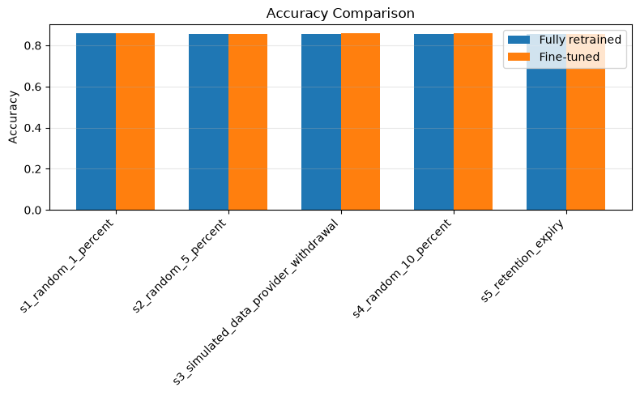

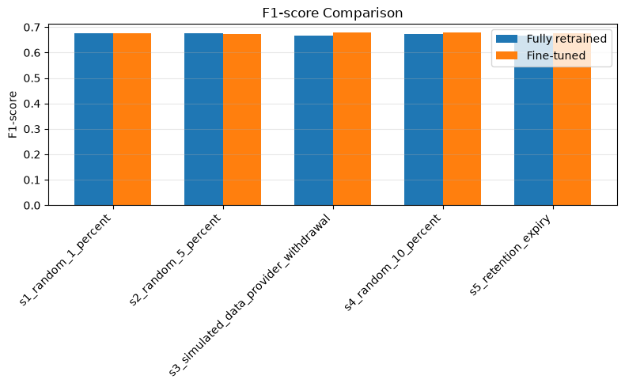

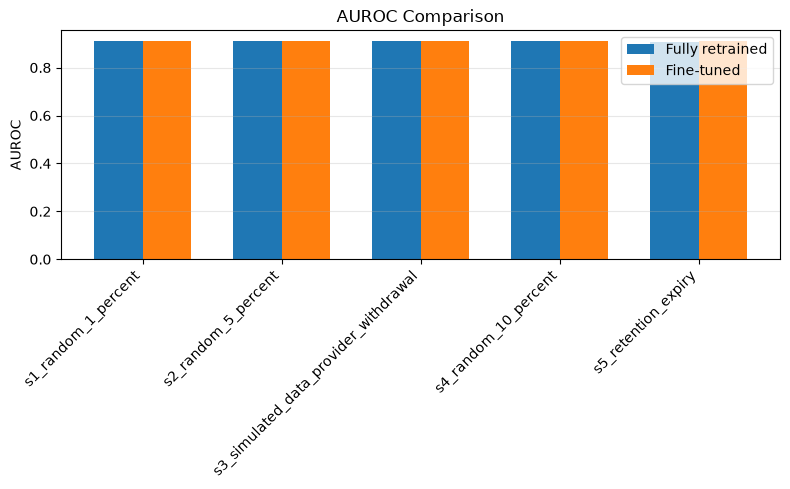

```python
plot_specs = [
    ("accuracy_comparison.png", "accuracy_retrained", "accuracy_finetuned", "Accuracy"),
    ("f1_comparison.png", "f1_score_retrained", "f1_score_finetuned", "F1-score"),
    ("auroc_comparison.png", "roc_auc_retrained", "roc_auc_finetuned", "AUROC"),
]

for filename, retrained_col, finetuned_col, ylabel in plot_specs:
    fig, ax = plt.subplots(figsize=(8, 5))
    x_positions = np.arange(len(retain_finetuning_comparison))
    bar_width = 0.35

    ax.bar(
        x_positions - bar_width / 2,
        retain_finetuning_comparison[retrained_col],
        width=bar_width,
        label="Fully retrained",
    )
    ax.bar(
        x_positions + bar_width / 2,
        retain_finetuning_comparison[finetuned_col],
        width=bar_width,
        label="Fine-tuned",
    )
    ax.set_xticks(x_positions)
    ax.set_xticklabels(
        retain_finetuning_comparison["scenario"],
        rotation=45,
        ha="right",
    )
    ax.set_ylabel(ylabel)
    ax.set_title(f"{ylabel} Comparison")
    ax.legend()
    ax.grid(axis="y", alpha=0.3)
    fig.tight_layout()
    fig.savefig(
        finetuning_figures_dir / filename,
        dpi=300,
        bbox_inches="tight",
    )
    plt.show()
```

**Runtime comparison figure**

The runtime comparison figure is saved to document computational cost. It compares fine-tuning time with full-retraining time for the same deletion scenarios.

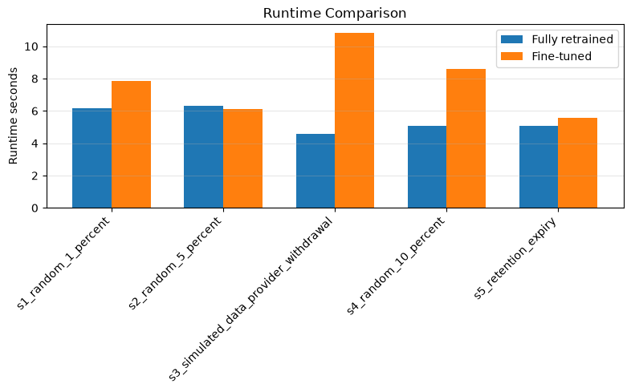

```python
runtime_fig, runtime_ax = plt.subplots(figsize=(8, 5))
x_positions = np.arange(len(runtime_comparison))
bar_width = 0.35
runtime_ax.bar(
    x_positions - bar_width / 2,
    runtime_comparison["runtime_seconds_retrained"],
    width=bar_width,
    label="Fully retrained",
)
runtime_ax.bar(
    x_positions + bar_width / 2,
    runtime_comparison["runtime_seconds_finetuned"],
    width=bar_width,
    label="Fine-tuned",
)
runtime_ax.set_xticks(x_positions)
runtime_ax.set_xticklabels(
    runtime_comparison["scenario"],
    rotation=45,
    ha="right",
)
runtime_ax.set_ylabel("Runtime seconds")
runtime_ax.set_title("Runtime Comparison")
runtime_ax.legend()
runtime_ax.grid(axis="y", alpha=0.3)
runtime_fig.tight_layout()
runtime_fig.savefig(
    finetuning_figures_dir / "runtime_comparison.png",
    dpi=300,
    bbox_inches="tight",
)
plt.show()
```

**Prediction agreement figure**

The prediction agreement figure is saved to show class-label similarity between models. This supports the behavioural comparison with the fully retrained reference.

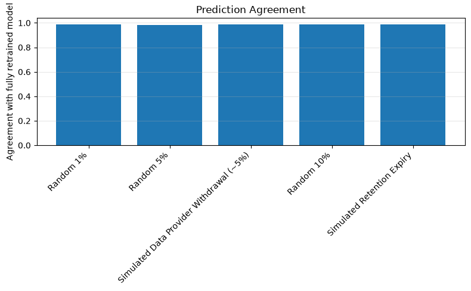

```python
agreement_fig, agreement_ax = plt.subplots(figsize=(8, 5))

x_positions = np.arange(len(prediction_agreement))
display_labels = prediction_agreement["scenario"].map(
    scenario_display_names
)

agreement_ax.bar(
    x_positions,
    prediction_agreement["prediction_agreement"],
)
agreement_ax.set_xticks(x_positions)
agreement_ax.set_xticklabels(
    display_labels,
    rotation=45,
    ha="right",
)
agreement_ax.set_ylabel("Agreement with fully retrained model")
agreement_ax.set_title("Prediction Agreement")
agreement_ax.grid(axis="y", alpha=0.3)

agreement_fig.tight_layout()
agreement_fig.savefig(
    finetuning_figures_dir / "prediction_agreement.png",
    dpi=300,
    bbox_inches="tight",
)
plt.show()
```

**Probability similarity figure**

The probability similarity figure is saved to show how closely fine-tuned probabilities match full retraining. This provides a probability-level view of forget-set fidelity.

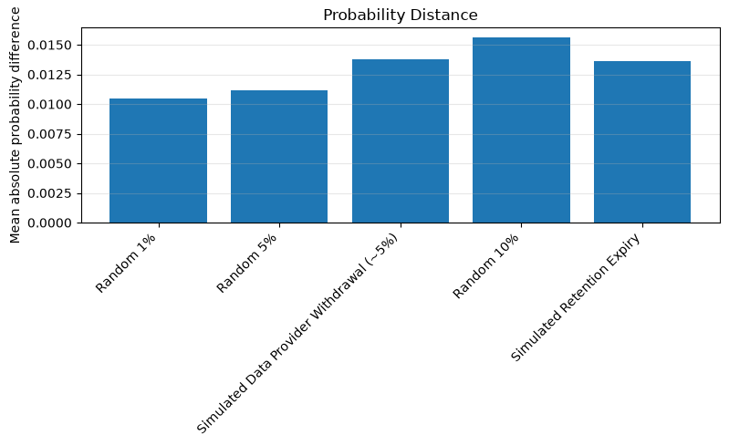

```
Saved figures to: ../../results/retain_finetuning/adult/figures
```

```python
probability_distance_fig, probability_distance_ax = plt.subplots(
    figsize=(8, 5)
)

x_positions = np.arange(len(probability_distance_summary))
display_labels = probability_distance_summary["scenario"].map(
    scenario_display_names
)

probability_distance_ax.bar(
    x_positions,
    probability_distance_summary[
        "mean_absolute_probability_difference"
    ],
)
probability_distance_ax.set_xticks(x_positions)
probability_distance_ax.set_xticklabels(
    display_labels,
    rotation=45,
    ha="right",
)
probability_distance_ax.set_ylabel(
    "Mean absolute probability difference"
)
probability_distance_ax.set_title("Probability Distance")
probability_distance_ax.grid(axis="y", alpha=0.3)

probability_distance_fig.tight_layout()
probability_distance_fig.savefig(
    finetuning_figures_dir / "probability_distance.png",
    dpi=300,
    bbox_inches="tight",
)
plt.show()

print(f"Saved figures to: {finetuning_figures_dir}")
```

# 10. Discussion

The discussion section interprets the results produced above. It follows the dissertation narrative from behavioural evidence, to utility preservation, to forgetfulness diagnostics and computational cost.

## 10.1 Overall Comparison

The following cells prepare visual summaries and scenario-level tables for the discussion. These outputs support the written interpretation that follows.

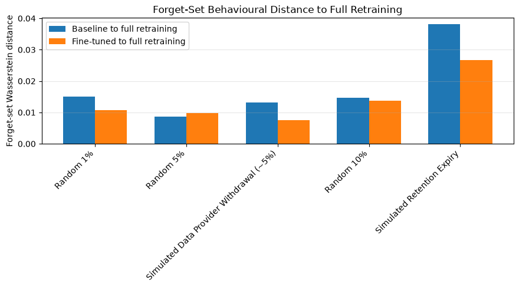

```
Saved behavioural summary figure to: ../../results/retain_finetuning/adult/figures/overall_discussion/overall_behavioural_wasserstein.png
```

```python
overall_discussion_figures_dir = finetuning_figures_dir / "overall_discussion"
overall_discussion_figures_dir.mkdir(parents=True, exist_ok=True)

behaviour_summary = retain_finetuning_unlearning_evaluation.copy()
behaviour_summary["display_name"] = behaviour_summary["scenario"].map(
    scenario_display_names
)

fig, ax = plt.subplots(figsize=(9, 5))
x_positions = np.arange(len(behaviour_summary))
bar_width = 0.35

ax.bar(
    x_positions - bar_width / 2,
    behaviour_summary["original_retrain_forget_wasserstein"],
    width=bar_width,
    label="Baseline to full retraining",
)
ax.bar(
    x_positions + bar_width / 2,
    behaviour_summary["forget_wasserstein"],
    width=bar_width,
    label="Fine-tuned to full retraining",
)
ax.set_xticks(x_positions)
ax.set_xticklabels(behaviour_summary["display_name"], rotation=45, ha="right")
ax.set_ylabel("Forget-set Wasserstein distance")
ax.set_title("Forget-Set Behavioural Distance to Full Retraining")
ax.legend()
ax.grid(axis="y", alpha=0.3)
fig.tight_layout()
behaviour_summary_path = overall_discussion_figures_dir / "overall_behavioural_wasserstein.png"
fig.savefig(behaviour_summary_path, dpi=300, bbox_inches="tight")
plt.show()

print(f"Saved behavioural summary figure to: {behaviour_summary_path}")
```

**Behavioural findings**

Retain-set fine-tuning produced models that remained generally close to the corresponding fully retrained models. Across the complete test set, prediction agreement ranged from approximately 98.35% to 98.99%, while the mean absolute probability difference remained below 0.016 in every scenario. These values show that the models behaved similarly overall, although high agreement alone does not demonstrate forgetting because the original baseline model was also close to full retraining in several scenarios.

The forget-set comparison provides a more detailed picture. In S1, prediction agreement with full retraining remained unchanged at 98.83%, while probability distance increased slightly from 0.0109 to 0.0110. Fine-tuning therefore provided no meaningful behavioural improvement in this scenario. S2 showed a small improvement: agreement increased from 98.42% to 98.65%, and probability distance decreased from 0.0134 to 0.0117.

The result for S3 was mixed. Prediction agreement improved from 98.53% to 98.70%, but probability distance increased from 0.0131 to 0.0141. This means that more class labels matched full retraining, but the underlying predicted probabilities did not become closer. S4 showed a small deterioration on both measures, with agreement decreasing from 98.51% to 98.36% and probability distance increasing from 0.0146 to 0.0151.

S5 provided the clearest behavioural improvement. Agreement with full retraining increased from 94.57% for the baseline model to 96.04% after fine-tuning, while probability distance decreased from 0.0361 to 0.0278. S5 created a larger initial difference between the baseline and fully retrained models because its forget set represented a structured and distributionally distinct group. Fine-tuning therefore had a clearer change to reproduce than in the random-deletion scenarios.

The epoch sweep also showed that checkpoint selection affects the result. Probability, loss and entropy selected epoch 2 as the best positive fine-tuning checkpoint for S1–S4 and epoch 5 for S5. However, the validation-selected checkpoint matched this choice only in S1. Validation loss selects the model with the best general predictive performance, whereas the other criteria select the model most similar to full retraining on the forget set. Utility-based early stopping may therefore preserve performance without selecting the checkpoint that provides the strongest unlearning evidence.

The different behavioural measures did not always agree. Distribution-level Wasserstein distance moved closer to full retraining in four scenarios, whereas record-level probability and prediction-agreement measures produced more mixed results. This is not necessarily contradictory: two models can have similar overall output distributions while assigning different probabilities to individual records. Behavioural evidence should therefore be considered across multiple measurements.

**Utility findings**

Retain-set fine-tuning preserved predictive utility in all five scenarios. Test accuracy remained between 85.60% and 85.83%, F1 score remained between 0.6731 and 0.6782, and AUROC remained close to 0.910.

Compared with the original baseline, changes in accuracy, F1 score and AUROC were small. The largest reduction in F1 score was approximately 0.20 percentage points in S2, while the largest improvement was approximately 0.31 percentage points in S4. AUROC was effectively unchanged across all scenarios.

The fine-tuned models also remained close to their fully retrained references. F1 differences did not exceed approximately 1.01 percentage points, and AUROC differences did not exceed approximately 0.12 percentage points. These results show that retain-set fine-tuning did not meaningfully damage the model’s ability to predict income on unseen test records.

Utility preservation must nevertheless be separated from evidence of forgetting. A model can retain high accuracy while continuing to behave like the original baseline on the forget records. The utility results demonstrate that fine-tuning is safe in terms of predictive performance, but they do not establish that unlearning was successful.

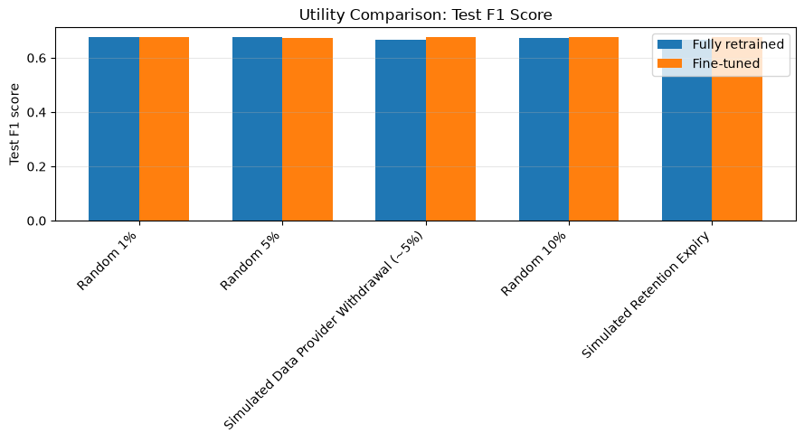

```
Saved utility summary figure to: ../../results/retain_finetuning/adult/figures/overall_discussion/overall_utility_f1.png
```

```python
utility_summary = retain_finetuning_comparison.copy()
utility_summary["display_name"] = utility_summary["scenario"].map(
    scenario_display_names
)

fig, ax = plt.subplots(figsize=(9, 5))
x_positions = np.arange(len(utility_summary))
bar_width = 0.35

ax.bar(
    x_positions - bar_width / 2,
    utility_summary["f1_score_retrained"],
    width=bar_width,
    label="Fully retrained",
)
ax.bar(
    x_positions + bar_width / 2,
    utility_summary["f1_score_finetuned"],
    width=bar_width,
    label="Fine-tuned",
)
ax.set_xticks(x_positions)
ax.set_xticklabels(utility_summary["display_name"], rotation=45, ha="right")
ax.set_ylabel("Test F1 score")
ax.set_title("Utility Comparison: Test F1 Score")
ax.legend()
ax.grid(axis="y", alpha=0.3)
fig.tight_layout()
utility_summary_path = overall_discussion_figures_dir / "overall_utility_f1.png"
fig.savefig(utility_summary_path, dpi=300, bbox_inches="tight")
plt.show()

print(f"Saved utility summary figure to: {utility_summary_path}")
```

**Forgetfulness findings**

Entropy provided scenario-dependent evidence. For the validation-selected checkpoints, relative entropy improvement was negative for S1, S2, S3 and S4. This means that the entropy values moved further from those of full retraining rather than closer. The random scenarios therefore did not provide entropy-based evidence of forgetting at their selected checkpoints.

S3 showed some potential during the epoch sweep. Epoch 2 improved entropy distance by approximately 12.53%, but the validation-selected checkpoint was epoch 4, where the relative improvement was negative. This reinforces the finding that validation loss does not necessarily select the checkpoint with the strongest forget-set similarity.

S5 produced the strongest entropy evidence. Its validation-selected checkpoint improved entropy distance to full retraining by approximately 23.95%, while epoch 5 produced an improvement of approximately 39.45%. A majority of S5 forget records also moved closer to the fully retrained entropy values. Together with the behavioural results, this provides evidence that fine-tuning reduced the difference between the baseline and retrained models for S5.

The membership-inference results cannot be used as evidence of successful forgetting. Loss-based attack AUROC was close to chance for S1–S4, while S5 produced an elevated value of approximately 0.596. However, the fully retrained S5 model produced a similarly elevated result of approximately 0.593. This suggests that the attack was detecting the unusual distribution of the S5 cohort rather than whether those records were used during training.

More importantly, the deliberately overfitted positive-control model produced an AUROC of only 0.4899. The attack therefore failed to detect membership even when a stronger membership signal was expected. As a result, all membership-inference findings must be treated as inconclusive. Near-chance MIA performance cannot demonstrate forgetting when the attack itself has not been shown to work reliably in this experimental setting.

Overall, the forgetfulness evidence is strongest for S5, limited for S3 and weak or absent for the random scenarios. Even for S5, the results provide empirical evidence consistent with approximate unlearning rather than proof that the influence of every forget record has been removed.

| Scenario | Overall interpretation |
| --- | --- |
| S1 – Random 1% | Utility was preserved, but behavioural and entropy results provided no meaningful evidence of forgetting. |
| S2 – Random 5% | Utility was preserved and behaviour improved slightly, but entropy did not move closer to full retraining. |
| S3 – Provider withdrawal | Behavioural results were mixed. Entropy improved at epoch 2, but not at the validation-selected checkpoint. |
| S4 – Random 10% | Utility was preserved, but forget-set behaviour and entropy were slightly worse than the baseline reference. |
| S5 – Retention expiry | Strongest evidence: behaviour and entropy both moved towards full retraining, although MIA remained inconclusive. |

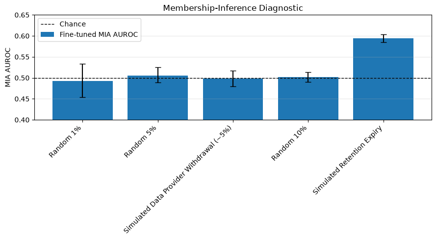

```
Saved MIA summary figure to: ../../results/retain_finetuning/adult/figures/overall_discussion/overall_mia_auroc.png
```

```python
mia_summary = retain_finetuning_unlearning_evaluation.copy()
mia_summary["display_name"] = mia_summary["scenario"].map(scenario_display_names)

fig, ax = plt.subplots(figsize=(9, 5))
x_positions = np.arange(len(mia_summary))
yerr = np.vstack(
    [
        mia_summary["mia_auroc"] - mia_summary["mia_auc_ci_low"],
        mia_summary["mia_auc_ci_high"] - mia_summary["mia_auroc"],
    ]
)

ax.bar(
    x_positions,
    mia_summary["mia_auroc"],
    yerr=yerr,
    capsize=4,
    label="Fine-tuned MIA AUROC",
)
ax.axhline(0.5, color="black", linestyle="--", linewidth=1, label="Chance")
ax.set_xticks(x_positions)
ax.set_xticklabels(mia_summary["display_name"], rotation=45, ha="right")
ax.set_ylim(0.4, max(0.65, mia_summary["mia_auc_ci_high"].max() + 0.03))
ax.set_ylabel("MIA AUROC")
ax.set_title("Membership-Inference Diagnostic")
ax.legend()
ax.grid(axis="y", alpha=0.3)
fig.tight_layout()
mia_summary_path = overall_discussion_figures_dir / "overall_mia_auroc.png"
fig.savefig(mia_summary_path, dpi=300, bbox_inches="tight")
plt.show()

print(f"Saved MIA summary figure to: {mia_summary_path}")
```

**Computational findings**

These results should not be interpreted as showing that fine-tuning is inherently slower than full retraining. Fine-tuning used a batch size of 64, while full retraining used a batch size of 256. The methods also used different learning rates and early-stopping settings. The results therefore represent the observed cost of each configured method rather than a strictly controlled runtime benchmark.

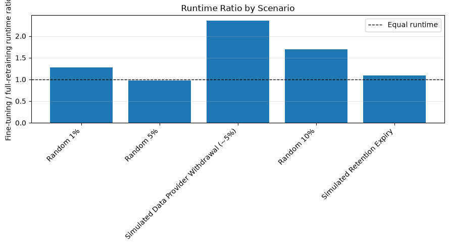

```
Saved runtime summary figure to: ../../results/retain_finetuning/adult/figures/overall_discussion/overall_runtime_ratio.png
```

```python
runtime_summary = runtime_comparison.copy()
runtime_summary["display_name"] = runtime_summary["scenario"].map(
    scenario_display_names
)

fig, ax = plt.subplots(figsize=(9, 5))
ax.bar(
    runtime_summary["display_name"],
    runtime_summary["runtime_ratio_finetuned_to_retrained"],
)
ax.axhline(1.0, color="black", linestyle="--", linewidth=1, label="Equal runtime")
ax.set_ylabel("Fine-tuning / full-retraining runtime ratio")
ax.set_title("Runtime Ratio by Scenario")
ax.set_xticklabels(runtime_summary["display_name"], rotation=45, ha="right")
ax.legend()
ax.grid(axis="y", alpha=0.3)
fig.tight_layout()
runtime_summary_path = overall_discussion_figures_dir / "overall_runtime_ratio.png"
fig.savefig(runtime_summary_path, dpi=300, bbox_inches="tight")
plt.show()

print(f"Saved runtime summary figure to: {runtime_summary_path}")
```